# Masterthesis script

Heleen Van Ransbeeck

2023-01-03

# Data inladen

```r
getwd()
```

```
## [1] "C:/Users/helee/OneDrive/Documenten/GitHub/vespa_analyses/Input"
```

```r
setwd("C:/Users/helee/OneDrive/Documenten/GitHub/vespa_analyses/Input")

Baits<-read.table(file = "Baits_useful.txt", header=TRUE, sep="\t", na.strings=c(""," ","NA"))

Flights_incomplete<-read.table(file = "Flights_incomplete.txt", header=TRUE, sep="\t", na.strings=c(""," ","NA"))

Nests<-read.table(file = "Nests_useful.txt", header=TRUE, sep="\t", na.strings=c(""," ","NA"))

Shortind_incomplete<-read.table(file = "Shortind_incomplete.txt", header=TRUE, sep="\t", na.strings=c(""," ","NA"))

Shortpot_incomplete<-read.table(file = "Shortpot_incomplete.txt", header=TRUE, sep="\t", na.strings=c(""," ","NA"))

Individuals<-read.table(file = "Individuals.txt", header=TRUE, sep="\t", na.strings=c(""," ","NA"))
```

-incomplete wil zeggen dat de weergegeves nog niet volledig zijn. Ik wacht hiervoor op het KMI.

# Aanpassingen datasets

```r
# Overbodige kolommen wegdoen, foutje in excel
Flights_incomplete<-Flights_incomplete[1:(length(Flights_incomplete)-2)]
Shortind_incomplete<-Shortind_incomplete[1:(length(Shortind_incomplete)-2)]
Shortpot_incomplete<-Shortpot_incomplete[1:(length(Shortpot_incomplete)-2)]

#Snelheid (m/s) toevoegen aan tabel
Flights_incomplete$Speed<-Flights_incomplete$Distance/(Flights_incomplete$Flighttime_min*60)
Shortind_incomplete$Speed<-Shortind_incomplete$Distance/(Shortind_incomplete$Flighttime_min*60)
Shortpot_incomplete$Speed<-Shortpot_incomplete$Distance/(Shortpot_incomplete$Flighttime_min*60)

# Procent symbolen cloudcoverage vervangen door komma getallen
Flights_incomplete$Cloudcoverage<- as.numeric(sub("%", "",Flights_incomplete$Cloudcoverage,fixed=TRUE))/100
Shortind_incomplete$Cloudcoverage<- as.numeric(sub("%", "",Shortind_incomplete$Cloudcoverage,fixed=TRUE))/100
Shortpot_incomplete$Cloudcoverage<- as.numeric(sub("%", "",Shortpot_incomplete$Cloudcoverage,fixed=TRUE))/100

## Urbanisatiecirkels per vliegtijd toevoegen
Flights_incomplete<-merge(Flights_incomplete, Baits[, c("NestID", "BaitID", "Urbanisation25m", "Urbanisation50m", "Urbanisation100m")], by=c("NestID", "BaitID"), all=TRUE)
Shortind_incomplete<-merge(Shortind_incomplete, Baits[, c("NestID", "BaitID", "Urbanisation25m", "Urbanisation50m", "Urbanisation100m")], by=c("NestID", "BaitID"), all=TRUE)
Shortpot_incomplete<-merge(Shortpot_incomplete, Baits[, c("NestID", "BaitID", "Urbanisation25m", "Urbanisation50m", "Urbanisation100m")], by=c("NestID", "BaitID"), all=TRUE)

## Urbanisatietrajecten per vliegtijd toevoegen
Flights_incomplete<-merge(Flights_incomplete, Baits[, c("NestID", "BaitID", "Traject25m", "Traject50m", "Traject100m")], by=c("NestID", "BaitID"), all=TRUE)
Shortind_incomplete<-merge(Shortind_incomplete, Baits[, c("NestID", "BaitID", "Traject25m", "Traject50m", "Traject100m")], by=c("NestID", "BaitID"), all=TRUE)
Shortpot_incomplete<-merge(Shortpot_incomplete, Baits[, c("NestID", "BaitID", "Traject25m", "Traject50m", "Traject100m")], by=c("NestID", "BaitID"), all=TRUE)

## Gewicht individu per vliegtijd toevoegen
Flights_incomplete<-merge(Flights_incomplete, Individuals[, c("NestID", "BaitID","ColorInd", "Weight_ind")], by=c("NestID", "BaitID", "ColorInd"), all=TRUE)
Shortind_incomplete<-merge(Shortind_incomplete, Individuals[, c("NestID", "BaitID", "ColorInd", "Weight_ind")], by=c("NestID", "BaitID", "ColorInd"), all=TRUE)
Shortpot_incomplete<-merge(Shortpot_incomplete, Individuals[, c("NestID", "BaitID", "ColorInd","Weight_ind")], by=c("NestID", "BaitID", "ColorInd"), all=TRUE)

## Nesthoogte per vliegtijd toevoegen
Flights_incomplete<-merge(Flights_incomplete, Nests[, c("NestID", "Height")], by=c("NestID"), all=TRUE)
Shortind_incomplete<-merge(Shortind_incomplete, Nests[, c("NestID", "Height")], by=c("NestID"), all=TRUE)
Shortpot_incomplete<-merge(Shortpot_incomplete, Nests[, c("NestID", "Height")], by=c("NestID"), all=TRUE)
```

# Datapunten op 2km weglaten?

Deze metingen zijn nogal onzeker omdat deze waarnemingen ook van een ander nest kunnen komen. Was op 2km afstand en in Melle zijn toch redelijk wat nesten gevonden. Kans dat het van een nest is dat niet gevonden werd is groot.

Als de website van Vespawatch in orde is kan ik kijken of er eventueel een nest in de buurt is gevonden.

```r
library(dplyr)
Flights2_incomplete<-Flights_incomplete %>%  filter(NestID!=1)
Shortind2_incomplete<-Shortind_incomplete %>%  filter(NestID!=1)
Shortpot2_incomplete<-Shortpot_incomplete %>%  filter(NestID!=1)
```

# Data exploratie

## 1) Flight time vs distance

### Graphs

Grafieken met en zonder outliers telkens voor de volgende datasets - volledige dataset - enkel kortste vliegtijden per individu - enkel kortste vliegtijden per wiekpot

Oranje lijn stelt de theoretische regel “1min vliegtijd is 100m tot het nest” voor.

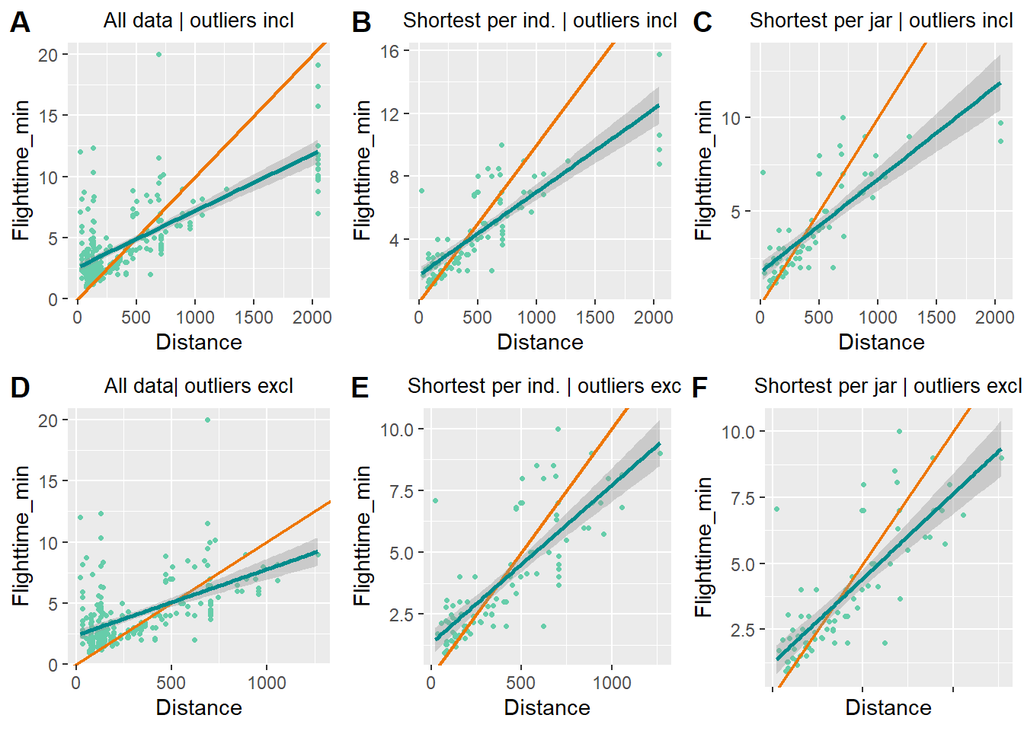

De datapunten uit Melle hebben duidelijk een groot effect op de regressielijn. Ze wijkt meer af van de theoretische oranje lijn.

### Model Output

**All data**

```r
# outliers incl
model_dist_all<-lm(Flighttime_min ~ Distance, na.action=na.exclude, data=Flights_incomplete)
summary(model_dist_all)
```

```
##
## Call:
## lm(formula = Flighttime_min ~ Distance, data = Flights_incomplete,
##     na.action = na.exclude)
##
## Residuals:
##     Min      1Q  Median      3Q     Max
## -5.0288 -1.3593 -0.7320  0.5535 14.2535
##
## Coefficients:
##              Estimate Std. Error t value Pr(>|t|)
## (Intercept) 2.5706197  0.1927892   13.33   <2e-16 ***
## Distance    0.0046228  0.0002907   15.90   <2e-16 ***
## ---
## Signif. codes:  0 '***' 0.001 '**' 0.01 '*' 0.05 '.' 0.1 ' ' 1
##
## Residual standard error: 2.383 on 254 degrees of freedom
##   (35 observations deleted due to missingness)
## Multiple R-squared:  0.499,  Adjusted R-squared:  0.497
## F-statistic:   253 on 1 and 254 DF,  p-value: < 2.2e-16
```

```r
# outliers excl
model_dist_all2<-lm(Flighttime_min ~ Distance, na.action=na.exclude, data=Flights2_incomplete)
summary(model_dist_all2)
```

```
##
## Call:
## lm(formula = Flighttime_min ~ Distance, data = Flights2_incomplete,
##     na.action = na.exclude)
##
## Residuals:
##     Min      1Q  Median      3Q     Max
## -3.7097 -1.2822 -0.8055  0.5184 13.9234
##
## Coefficients:
##             Estimate Std. Error t value Pr(>|t|)
## (Intercept) 2.370329   0.228807   10.36   <2e-16 ***
## Distance    0.005395   0.000577    9.35   <2e-16 ***
## ---
## Signif. codes:  0 '***' 0.001 '**' 0.01 '*' 0.05 '.' 0.1 ' ' 1
##
## Residual standard error: 2.325 on 236 degrees of freedom
##   (30 observations deleted due to missingness)
## Multiple R-squared:  0.2703, Adjusted R-squared:  0.2672
## F-statistic: 87.42 on 1 and 236 DF,  p-value: < 2.2e-16
```

Beide hoog significant

```r
# Mixed model, Observer, Nest en Individuele variatie in rekening brengen
library(lmerTest)
library(lme4)
Flights_incomplete$NestID<-as.factor(Flights_incomplete$NestID)
Flights_incomplete$BaitID<-as.factor(Flights_incomplete$BaitID)
Flights_incomplete$ColorInd<-as.factor(Flights_incomplete$ColorInd)

mixedobserver<-lmer(Flighttime_min ~ Distance + (1|Observer) + (1|NestID) + (1|ColorInd:BaitID:NestID), data=Flights_incomplete)
```

```
## boundary (singular) fit: see help('isSingular')
```

```r
summary(mixedobserver)
```

```
## Linear mixed model fit by REML. t-tests use Satterthwaite's method [
## lmerModLmerTest]
## Formula: Flighttime_min ~ Distance + (1 | Observer) + (1 | NestID) + (1 |
##     ColorInd:BaitID:NestID)
##    Data: Flights_incomplete
##
## REML criterion at convergence: 1121.3
##
## Scaled residuals:
##     Min      1Q  Median      3Q     Max
## -2.4381 -0.4169 -0.1511  0.1920  4.4376
##
## Random effects:
##  Groups                 Name        Variance Std.Dev.
##  ColorInd:BaitID:NestID (Intercept) 1.9025   1.3793
##  NestID                 (Intercept) 0.7686   0.8767
##  Observer               (Intercept) 0.0000   0.0000
##  Residual                           3.0308   1.7409
## Number of obs: 256, groups:
## ColorInd:BaitID:NestID, 99; NestID, 35; Observer, 2
##
## Fixed effects:
##              Estimate Std. Error        df t value Pr(>|t|)
## (Intercept) 2.400e+00  3.758e-01 1.401e+01   6.386 1.69e-05 ***
## Distance    4.964e-03  5.472e-04 1.312e+01   9.072 5.12e-07 ***
## ---
## Signif. codes:  0 '***' 0.001 '**' 0.01 '*' 0.05 '.' 0.1 ' ' 1
##
## Correlation of Fixed Effects:
##          (Intr)
## Distance -0.717
## optimizer (nloptwrap) convergence code: 0 (OK)
## boundary (singular) fit: see help('isSingular')
```

```r
anova(mixedobserver, ddf="Satterthwaite", type=3)
```

```
## Type III Analysis of Variance Table with Satterthwaite's method
##          Sum Sq Mean Sq NumDF  DenDF F value    Pr(>F)
## Distance 249.44  249.44     1 13.123  82.299 5.116e-07 ***
## ---
## Signif. codes:  0 '***' 0.001 '**' 0.01 '*' 0.05 '.' 0.1 ' ' 1
```

Variatie tussen de waarnemers bleek niet groot te zijn (0).

**Shortest per individual**

```r
# outliers incl
model_dist_ind<-lm(Flighttime_min ~ Distance, na.action=na.exclude, data=Shortind_incomplete)
summary(model_dist_ind)
```

```
##
## Call:
## lm(formula = Flighttime_min ~ Distance, data = Shortind_incomplete,
##     na.action = na.exclude)
##
## Residuals:
##     Min      1Q  Median      3Q     Max
## -3.7675 -0.9172 -0.3891  0.4777  5.2581
##
## Coefficients:
##              Estimate Std. Error t value Pr(>|t|)
## (Intercept) 1.7245632  0.2376095   7.258 1.02e-10 ***
## Distance    0.0052835  0.0003714  14.225  < 2e-16 ***
## ---
## Signif. codes:  0 '***' 0.001 '**' 0.01 '*' 0.05 '.' 0.1 ' ' 1
##
## Residual standard error: 1.579 on 96 degrees of freedom
##   (43 observations deleted due to missingness)
## Multiple R-squared:  0.6782, Adjusted R-squared:  0.6749
## F-statistic: 202.3 on 1 and 96 DF,  p-value: < 2.2e-16
```

```r
# outliers excl
model_dist_ind2<-lm(Flighttime_min ~ Distance, na.action=na.exclude, data=Shortind2_incomplete)
summary(model_dist_ind2)
```

```
##
## Call:
## lm(formula = Flighttime_min ~ Distance, data = Shortind2_incomplete,
##     na.action = na.exclude)
##
## Residuals:
##     Min      1Q  Median      3Q     Max
## -3.2832 -0.8609 -0.4894  0.4123  5.6289
##
## Coefficients:
##              Estimate Std. Error t value Pr(>|t|)
## (Intercept) 1.3328671  0.2590020   5.146  1.5e-06 ***
## Distance    0.0063817  0.0005192  12.292  < 2e-16 ***
## ---
## Signif. codes:  0 '***' 0.001 '**' 0.01 '*' 0.05 '.' 0.1 ' ' 1
##
## Residual standard error: 1.45 on 92 degrees of freedom
##   (41 observations deleted due to missingness)
## Multiple R-squared:  0.6216, Adjusted R-squared:  0.6174
## F-statistic: 151.1 on 1 and 92 DF,  p-value: < 2.2e-16
```

Beide hoogsignificant

**Shortest per jar**

```r
# outliers incl
model_dist_pot<-lm(Flighttime_min ~ Distance, na.action=na.exclude, data=Shortpot_incomplete)
summary(model_dist_pot)
```

```
##
## Call:
## lm(formula = Flighttime_min ~ Distance, data = Shortpot_incomplete,
##     na.action = na.exclude)
##
## Residuals:
##     Min      1Q  Median      3Q     Max
## -3.1443 -0.8938 -0.3108  0.4669  5.2350
##
## Coefficients:
##              Estimate Std. Error t value Pr(>|t|)
## (Intercept) 1.7536948  0.2700512   6.494 8.12e-09 ***
## Distance    0.0049646  0.0004571  10.861  < 2e-16 ***
## ---
## Signif. codes:  0 '***' 0.001 '**' 0.01 '*' 0.05 '.' 0.1 ' ' 1
##
## Residual standard error: 1.536 on 75 degrees of freedom
##   (67 observations deleted due to missingness)
## Multiple R-squared:  0.6113, Adjusted R-squared:  0.6061
## F-statistic:   118 on 1 and 75 DF,  p-value: < 2.2e-16
```

```r
# outliers excl
model_dist_pot2<-lm(Flighttime_min ~ Distance, na.action=na.exclude, data=Shortpot2_incomplete)
summary(model_dist_pot2)
```

```
##
## Call:
## lm(formula = Flighttime_min ~ Distance, data = Shortpot2_incomplete,
##     na.action = na.exclude)
##
## Residuals:
##     Min      1Q  Median      3Q     Max
## -3.2010 -0.7861 -0.4401  0.3939  5.7204
##
## Coefficients:
##              Estimate Std. Error t value Pr(>|t|)
## (Intercept) 1.2410549  0.2885056   4.302 5.18e-05 ***
## Distance    0.0063974  0.0005806  11.019  < 2e-16 ***
## ---
## Signif. codes:  0 '***' 0.001 '**' 0.01 '*' 0.05 '.' 0.1 ' ' 1
##
## Residual standard error: 1.431 on 73 degrees of freedom
##   (60 observations deleted due to missingness)
## Multiple R-squared:  0.6245, Adjusted R-squared:  0.6194
## F-statistic: 121.4 on 1 and 73 DF,  p-value: < 2.2e-16
```

Beide hoogsignificant

## 2) Speed vs Temperature

### Graphs

Grafieken met outliers telkens voor de volgende datasets - volledige dataset - enkel kortste vliegtijden per individu - enkel kortste vliegtijden per wiekpot

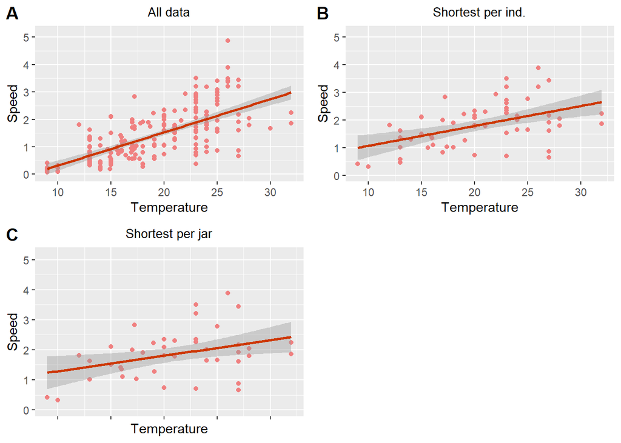

### Model Output

**All data**

```r
model_temp_all<-lm(Speed ~ Temperature, na.action=na.exclude, data=Flights_incomplete)
summary(model_temp_all)
```

```
##
## Call:
## lm(formula = Speed ~ Temperature, data = Flights_incomplete,
##     na.action = na.exclude)
##
## Residuals:
##     Min      1Q  Median      3Q     Max
## -1.7207 -0.3935 -0.1310  0.4681  2.6174
##
## Coefficients:
##              Estimate Std. Error t value Pr(>|t|)
## (Intercept) -0.888948   0.177380  -5.012 1.19e-06 ***
## Temperature  0.120883   0.009069  13.330  < 2e-16 ***
## ---
## Signif. codes:  0 '***' 0.001 '**' 0.01 '*' 0.05 '.' 0.1 ' ' 1
##
## Residual standard error: 0.6801 on 199 degrees of freedom
##   (90 observations deleted due to missingness)
## Multiple R-squared:  0.4717, Adjusted R-squared:  0.469
## F-statistic: 177.7 on 1 and 199 DF,  p-value: < 2.2e-16
```

Hoogsignificant

**Shortest per individual**

```r
model_temp_ind<-lm(Speed ~ Temperature, na.action=na.exclude, data=Shortind_incomplete)
summary(model_temp_ind)
```

```
##
## Call:
## lm(formula = Speed ~ Temperature, data = Shortind_incomplete,
##     na.action = na.exclude)
##
## Residuals:
##     Min      1Q  Median      3Q     Max
## -1.6431 -0.4861 -0.0632  0.4725  1.6642
##
## Coefficients:
##             Estimate Std. Error t value Pr(>|t|)
## (Intercept)  0.35670    0.36991   0.964 0.338971
## Temperature  0.07187    0.01747   4.114 0.000126 ***
## ---
## Signif. codes:  0 '***' 0.001 '**' 0.01 '*' 0.05 '.' 0.1 ' ' 1
##
## Residual standard error: 0.7212 on 57 degrees of freedom
##   (82 observations deleted due to missingness)
## Multiple R-squared:  0.2289, Adjusted R-squared:  0.2154
## F-statistic: 16.93 on 1 and 57 DF,  p-value: 0.0001265
```

Hoogsignificant

**Shortest per jar**

```r
model_temp_pot<-lm(Speed ~ Temperature, na.action=na.exclude, data=Shortpot_incomplete)
summary(model_temp_pot)
```

```
##
## Call:
## lm(formula = Speed ~ Temperature, data = Shortpot_incomplete,
##     na.action = na.exclude)
##
## Residuals:
##      Min       1Q   Median       3Q      Max
## -1.51299 -0.45956 -0.03983  0.43349  1.77401
##
## Coefficients:
##             Estimate Std. Error t value Pr(>|t|)
## (Intercept)  0.77441    0.44179   1.753   0.0871 .
## Temperature  0.05158    0.02036   2.533   0.0152 *
## ---
## Signif. codes:  0 '***' 0.001 '**' 0.01 '*' 0.05 '.' 0.1 ' ' 1
##
## Residual standard error: 0.7543 on 41 degrees of freedom
##   (101 observations deleted due to missingness)
## Multiple R-squared:  0.1353, Adjusted R-squared:  0.1142
## F-statistic: 6.416 on 1 and 41 DF,  p-value: 0.01523
```

Minder significant

## 3) Flight time vs Distance + Temperature

### Graph

```r
library(knitr)
library(kableExtra)
```

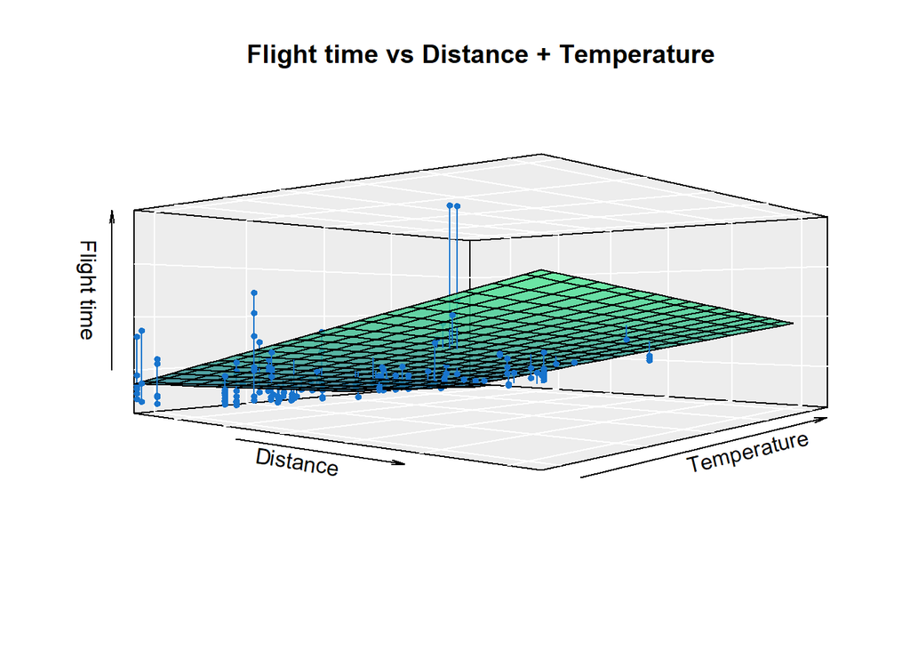

```r
library("plot3D")

x <- Flights2_incomplete$Distance
y <- Flights2_incomplete$Temperature
z <- Flights2_incomplete$Flighttime_min

fit <- lm(z ~ x + y, na.action=na.exclude)
x.pred <- seq(min(x[!is.na(x)]), max(x[!is.na(x)]), length.out = 20)
y.pred <- seq(min(y[!is.na(y)]), max(y[!is.na(y)]), length.out = 20)
xy <- expand.grid( x = x.pred, y = y.pred)
z.pred <- matrix(predict(fit, newdata = xy),
                 nrow = 20, ncol = 20)
fitpoints <- predict(fit)

scatter3D(x, y, z, pch = 19, cex = 0.6, colvar=FALSE, col="dodgerblue3", theta = 40, phi = 0, bty="u", col.panel ="grey93", expand =0.4, col.grid = "white", xlab = "Distance", ylab = "Temperature", zlab = "Flight time", surf = list(x = x.pred, y = y.pred, z = z.pred,
facets = TRUE, col=ramp.col(col = c("dodgerblue4", "seagreen2"), n = 100, alpha=0.8), fit = fitpoints, border="black"),main = "Flight time vs Distance + Temperature")
```

### Model Ouput

**All data**

```r
model_tempdist_all<-lm(Flighttime_min ~ Distance + Temperature, na.action=na.exclude, data=Flights_incomplete)
summary(model_tempdist_all)
```

```
##
## Call:
## lm(formula = Flighttime_min ~ Distance + Temperature, data = Flights_incomplete,
##     na.action = na.exclude)
##
## Residuals:
##     Min      1Q  Median      3Q     Max
## -4.9518 -1.2849 -0.5831  0.5585 13.8829
##
## Coefficients:
##               Estimate Std. Error t value Pr(>|t|)
## (Intercept)  5.3009856  0.6354036   8.343 1.22e-14 ***
## Distance     0.0053766  0.0003381  15.902  < 2e-16 ***
## Temperature -0.1673020  0.0355841  -4.702 4.83e-06 ***
## ---
## Signif. codes:  0 '***' 0.001 '**' 0.01 '*' 0.05 '.' 0.1 ' ' 1
##
## Residual standard error: 2.325 on 198 degrees of freedom
##   (90 observations deleted due to missingness)
## Multiple R-squared:  0.5729, Adjusted R-squared:  0.5686
## F-statistic: 132.8 on 2 and 198 DF,  p-value: < 2.2e-16
```

Beide Hoogsignificant

**Shortest per individual**

```r
model_tempdist_ind<-lm(Flighttime_min ~ Distance + Temperature, na.action=na.exclude, data=Shortind_incomplete)
summary(model_tempdist_ind)
```

```
##
## Call:
## lm(formula = Flighttime_min ~ Distance + Temperature, data = Shortind_incomplete,
##     na.action = na.exclude)
##
## Residuals:
##     Min      1Q  Median      3Q     Max
## -2.8050 -0.5057 -0.2068  0.2924  4.1539
##
## Coefficients:
##               Estimate Std. Error t value Pr(>|t|)
## (Intercept)  1.8651156  0.5596239   3.333  0.00153 **
## Distance     0.0051362  0.0003014  17.043  < 2e-16 ***
## Temperature -0.0308378  0.0278545  -1.107  0.27298
## ---
## Signif. codes:  0 '***' 0.001 '**' 0.01 '*' 0.05 '.' 0.1 ' ' 1
##
## Residual standard error: 1.087 on 56 degrees of freedom
##   (82 observations deleted due to missingness)
## Multiple R-squared:  0.8482, Adjusted R-squared:  0.8427
## F-statistic: 156.4 on 2 and 56 DF,  p-value: < 2.2e-16
```

Temperatuur niet significant

**Shortest per jar**

```r
model_tempdist_pot<-lm(Flighttime_min ~ Distance + Temperature, na.action=na.exclude, data=Shortpot_incomplete)
summary(model_tempdist_pot)
```

```
##
## Call:
## lm(formula = Flighttime_min ~ Distance + Temperature, data = Shortpot_incomplete,
##     na.action = na.exclude)
##
## Residuals:
##     Min      1Q  Median      3Q     Max
## -1.3779 -0.5577 -0.1773  0.2676  3.6174
##
## Coefficients:
##               Estimate Std. Error t value Pr(>|t|)
## (Intercept)  1.7670570  0.5425535   3.257   0.0023 **
## Distance     0.0042977  0.0003416  12.583 1.73e-15 ***
## Temperature -0.0159717  0.0256660  -0.622   0.5373
## ---
## Signif. codes:  0 '***' 0.001 '**' 0.01 '*' 0.05 '.' 0.1 ' ' 1
##
## Residual standard error: 0.926 on 40 degrees of freedom
##   (101 observations deleted due to missingness)
## Multiple R-squared:  0.8035, Adjusted R-squared:  0.7936
## F-statistic: 81.77 on 2 and 40 DF,  p-value: 7.389e-15
```

Temperatuur niet significant

## 4) Speed vs Height

### Graphs

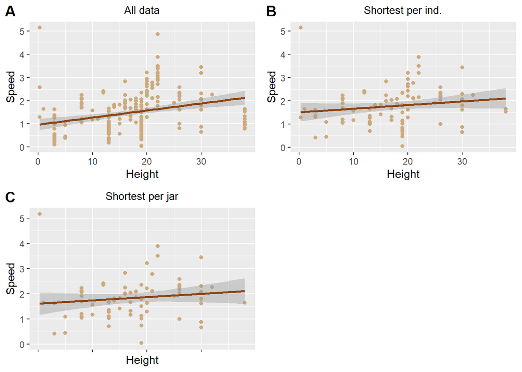

```r
plot10<-ggplot(Flights_incomplete, aes(x=Height, y=Speed)) + geom_point(color="burlywood3") + geom_smooth(method="lm", formula =y ~ x, se=TRUE, fullrange=FALSE, level=0.95, color="chocolate4") + ggtitle("All data")+ theme(plot.title = element_text(hjust = 0.5, size=10))

plot11<-ggplot(Shortind_incomplete, aes(x=Height, y=Speed)) + geom_point(color="burlywood3") + geom_smooth(method="lm", formula =y ~ x, se=TRUE, fullrange=FALSE, level=0.95, color="chocolate4") + ggtitle("Shortest per ind.") + theme(plot.title = element_text(hjust = 0.5, size=10))

plot12<-ggplot(Shortpot_incomplete, aes(x=Height, y=Speed)) + geom_point(color="burlywood3") + geom_smooth(method="lm", formula =y ~ x,  se=TRUE, fullrange=FALSE, level=0.95, color="chocolate4") + ggtitle("Shortest per jar")+ theme(plot.title = element_text(hjust = 0.5, size=10))

ggarrange(plot10, plot11, plot12 + rremove("x.text"),
          labels = c("A", "B", "C"),
          ncol = 2, nrow = 2)
```

### Model Ouput

**All data**

```r
model_height_all<-lm(Speed ~ Height, na.action=na.exclude, data=Flights_incomplete)
summary(model_height_all)
```

```
##
## Call:
## lm(formula = Speed ~ Height, data = Flights_incomplete, na.action = na.exclude)
##
## Residuals:
##     Min      1Q  Median      3Q     Max
## -1.5195 -0.6602 -0.0605  0.4713  4.1847
##
## Coefficients:
##             Estimate Std. Error t value Pr(>|t|)
## (Intercept) 0.964437   0.126667   7.614 5.95e-13 ***
## Height      0.030605   0.006773   4.519 9.73e-06 ***
## ---
## Signif. codes:  0 '***' 0.001 '**' 0.01 '*' 0.05 '.' 0.1 ' ' 1
##
## Residual standard error: 0.8607 on 242 degrees of freedom
##   (47 observations deleted due to missingness)
## Multiple R-squared:  0.07781,    Adjusted R-squared:  0.074
## F-statistic: 20.42 on 1 and 242 DF,  p-value: 9.733e-06
```

Hoogsignificant

**Shortest per individual**

```r
model_height_ind<-lm(Speed ~ Height, na.action=na.exclude, data=Shortind_incomplete)
summary(model_height_ind)
```

```
##
## Call:
## lm(formula = Speed ~ Height, data = Shortind_incomplete, na.action = na.exclude)
##
## Residuals:
##     Min      1Q  Median      3Q     Max
## -1.7641 -0.5503  0.0261  0.3833  3.6432
##
## Coefficients:
##             Estimate Std. Error t value Pr(>|t|)
## (Intercept)  1.51044    0.19802   7.628 1.91e-11 ***
## Height       0.01571    0.01023   1.535    0.128
## ---
## Signif. codes:  0 '***' 0.001 '**' 0.01 '*' 0.05 '.' 0.1 ' ' 1
##
## Residual standard error: 0.8107 on 94 degrees of freedom
##   (45 observations deleted due to missingness)
## Multiple R-squared:  0.02444,    Adjusted R-squared:  0.01406
## F-statistic: 2.355 on 1 and 94 DF,  p-value: 0.1282
```

Niet significant

**Shortest per jar**

```r
model_height_pot<-lm(Speed ~ Height, na.action=na.exclude, data=Shortpot_incomplete)
summary(model_height_pot)
```

```
##
## Call:
## lm(formula = Speed ~ Height, data = Shortpot_incomplete, na.action = na.exclude)
##
## Residuals:
##     Min      1Q  Median      3Q     Max
## -1.8127 -0.5121  0.0187  0.3380  3.5441
##
## Coefficients:
##             Estimate Std. Error t value Pr(>|t|)
## (Intercept)  1.61028    0.22435   7.178 4.87e-10 ***
## Height       0.01301    0.01158   1.124    0.265
## ---
## Signif. codes:  0 '***' 0.001 '**' 0.01 '*' 0.05 '.' 0.1 ' ' 1
##
## Residual standard error: 0.8129 on 73 degrees of freedom
##   (69 observations deleted due to missingness)
## Multiple R-squared:  0.01701,    Adjusted R-squared:  0.003543
## F-statistic: 1.263 on 1 and 73 DF,  p-value: 0.2647
```

Niet significant

## 5) Flight time vs Distance + Height

### Graphs

Height = height of the nest

```r
x <- Flights2_incomplete$Distance
y <- Flights2_incomplete$Height
z <- Flights2_incomplete$Flighttime_min

fit <- lm(z ~ x + y, na.action=na.exclude)
x.pred <- seq(min(x[!is.na(x)]), max(x[!is.na(x)]), length.out = 20)
y.pred <- seq(min(y[!is.na(y)]), max(y[!is.na(y)]), length.out = 20)
xy <- expand.grid( x = x.pred, y = y.pred)
z.pred <- matrix(predict(fit, newdata = xy),
                 nrow = 20, ncol = 20)
fitpoints <- predict(fit)

scatter3D(x, y, z, pch = 19, cex = 0.6, colvar=FALSE, col="dodgerblue3", theta = 40, phi = 15, bty="u", col.panel ="grey93", expand =0.4, col.grid = "white", xlab = "Distance", ylab = "Height", zlab = "Flight time", surf = list(x = x.pred, y = y.pred, z = z.pred,
facets = TRUE, col=ramp.col(col = c("dodgerblue4", "seagreen2"), n = 100, alpha=0.8), fit = fitpoints, border="black"),main = "Flight time vs Distance + Height")
```

[figure not shown]

### Model Output

**All data**

```r
model_distheight_all<-lm(Flighttime_min ~ Distance + Height , na.action=na.exclude, data=Flights_incomplete)
summary(model_distheight_all)
```

```
##
## Call:
## lm(formula = Flighttime_min ~ Distance + Height, data = Flights_incomplete,
##     na.action = na.exclude)
##
## Residuals:
##     Min      1Q  Median      3Q     Max
## -5.1083 -1.2871 -0.6099  0.6688 14.1182
##
## Coefficients:
##               Estimate Std. Error t value Pr(>|t|)
## (Intercept)  3.4580292  0.3511510   9.848  < 2e-16 ***
## Distance     0.0049069  0.0002963  16.561  < 2e-16 ***
## Height      -0.0631492  0.0188683  -3.347 0.000948 ***
## ---
## Signif. codes:  0 '***' 0.001 '**' 0.01 '*' 0.05 '.' 0.1 ' ' 1
##
## Residual standard error: 2.346 on 241 degrees of freedom
##   (47 observations deleted due to missingness)
## Multiple R-squared:  0.5323, Adjusted R-squared:  0.5284
## F-statistic: 137.1 on 2 and 241 DF,  p-value: < 2.2e-16
```

Height effect blijkt toch significant. In de negatieve zin weliswaar. Hoe hoger het nest hoe minder lang hij erover doet. Zou het omgekeerde verwachten..

```r
model_distheight2_all<-lm(Flighttime_min ~ sqrt(I(Distance^2) + I(Height^2)) , na.action=na.exclude, data=Flights_incomplete)
summary(model_distheight2_all)
```

```
##
## Call:
## lm(formula = Flighttime_min ~ sqrt(I(Distance^2) + I(Height^2)),
##     data = Flights_incomplete, na.action = na.exclude)
##
## Residuals:
##     Min      1Q  Median      3Q     Max
## -5.1070 -1.3105 -0.7159  0.5325 14.2879
##
## Coefficients:
##                                    Estimate Std. Error t value Pr(>|t|)
## (Intercept)                       2.4784546  0.2010200   12.33   <2e-16 ***
## sqrt(I(Distance^2) + I(Height^2)) 0.0047057  0.0002962   15.89   <2e-16 ***
## ---
## Signif. codes:  0 '***' 0.001 '**' 0.01 '*' 0.05 '.' 0.1 ' ' 1
##
## Residual standard error: 2.395 on 242 degrees of freedom
##   (47 observations deleted due to missingness)
## Multiple R-squared:  0.5105, Adjusted R-squared:  0.5085
## F-statistic: 252.4 on 1 and 242 DF,  p-value: < 2.2e-16
```

Model volgens Pythagoras? -> Hoogsignificant

**Shortest per individual**

```r
model_distheight_ind<-lm(Flighttime_min ~ Distance + Height , na.action=na.exclude, data=Shortind_incomplete)
summary(model_distheight_ind)
```

```
##
## Call:
## lm(formula = Flighttime_min ~ Distance + Height, data = Shortind_incomplete,
##     na.action = na.exclude)
##
## Residuals:
##     Min      1Q  Median      3Q     Max
## -3.6673 -0.8863 -0.3574  0.4773  5.3325
##
## Coefficients:
##               Estimate Std. Error t value Pr(>|t|)
## (Intercept)  2.3657366  0.4141182   5.713 1.33e-07 ***
## Distance     0.0053265  0.0003732  14.272  < 2e-16 ***
## Height      -0.0377076  0.0199207  -1.893   0.0615 .
## ---
## Signif. codes:  0 '***' 0.001 '**' 0.01 '*' 0.05 '.' 0.1 ' ' 1
##
## Residual standard error: 1.574 on 93 degrees of freedom
##   (45 observations deleted due to missingness)
## Multiple R-squared:  0.6874, Adjusted R-squared:  0.6807
## F-statistic: 102.2 on 2 and 93 DF,  p-value: < 2.2e-16
```

Height niet significant

```r
model_distheight2_ind<-lm(Flighttime_min ~ sqrt(I(Distance^2) + I(Height^2)) , na.action=na.exclude, data=Shortind_incomplete)
summary(model_distheight2_ind)
```

```
##
## Call:
## lm(formula = Flighttime_min ~ sqrt(I(Distance^2) + I(Height^2)),
##     data = Shortind_incomplete, na.action = na.exclude)
##
## Residuals:
##     Min      1Q  Median      3Q     Max
## -3.7630 -0.9198 -0.4505  0.5051  5.2220
##
## Coefficients:
##                                    Estimate Std. Error t value Pr(>|t|)
## (Intercept)                       1.7190789  0.2432514   7.067 2.74e-10 ***
## sqrt(I(Distance^2) + I(Height^2)) 0.0052836  0.0003777  13.990  < 2e-16 ***
## ---
## Signif. codes:  0 '***' 0.001 '**' 0.01 '*' 0.05 '.' 0.1 ' ' 1
##
## Residual standard error: 1.595 on 94 degrees of freedom
##   (45 observations deleted due to missingness)
## Multiple R-squared:  0.6756, Adjusted R-squared:  0.6721
## F-statistic: 195.7 on 1 and 94 DF,  p-value: < 2.2e-16
```

Hoogsignificant

**Shortest per jar**

```r
model_distheight_pot<-lm(Flighttime_min ~ Distance + Height , na.action=na.exclude, data=Shortpot_incomplete)
summary(model_distheight_pot)
```

```
##
## Call:
## lm(formula = Flighttime_min ~ Distance + Height, data = Shortpot_incomplete,
##     na.action = na.exclude)
##
## Residuals:
##     Min      1Q  Median      3Q     Max
## -3.5430 -0.8069 -0.3762  0.4120  5.2924
##
## Coefficients:
##               Estimate Std. Error t value Pr(>|t|)
## (Intercept)  2.4879739  0.4696848   5.297 1.23e-06 ***
## Distance     0.0049556  0.0004586  10.806  < 2e-16 ***
## Height      -0.0416600  0.0217650  -1.914   0.0596 .
## ---
## Signif. codes:  0 '***' 0.001 '**' 0.01 '*' 0.05 '.' 0.1 ' ' 1
##
## Residual standard error: 1.528 on 72 degrees of freedom
##   (69 observations deleted due to missingness)
## Multiple R-squared:  0.6255, Adjusted R-squared:  0.6151
## F-statistic: 60.13 on 2 and 72 DF,  p-value: 4.402e-16
```

Height niet significant

```r
model_distheight2_pot<-lm(Flighttime_min ~ sqrt(I(Distance^2) + I(Height^2)) , na.action=na.exclude, data=Shortpot_incomplete)
summary(model_distheight2_pot)
```

```
##
## Call:
## lm(formula = Flighttime_min ~ sqrt(I(Distance^2) + I(Height^2)),
##     data = Shortpot_incomplete, na.action = na.exclude)
##
## Residuals:
##     Min      1Q  Median      3Q     Max
## -3.1297 -0.8929 -0.3967  0.4954  5.2010
##
## Coefficients:
##                                    Estimate Std. Error t value Pr(>|t|)
## (Intercept)                       1.7487324  0.2781800   6.286 2.13e-08 ***
## sqrt(I(Distance^2) + I(Height^2)) 0.0049596  0.0004672  10.615  < 2e-16 ***
## ---
## Signif. codes:  0 '***' 0.001 '**' 0.01 '*' 0.05 '.' 0.1 ' ' 1
##
## Residual standard error: 1.555 on 73 degrees of freedom
##   (69 observations deleted due to missingness)
## Multiple R-squared:  0.6068, Adjusted R-squared:  0.6015
## F-statistic: 112.7 on 1 and 73 DF,  p-value: < 2.2e-16
```

Hoogsignificant

## 6) Speed vs Cloudcoverage

### Graphs

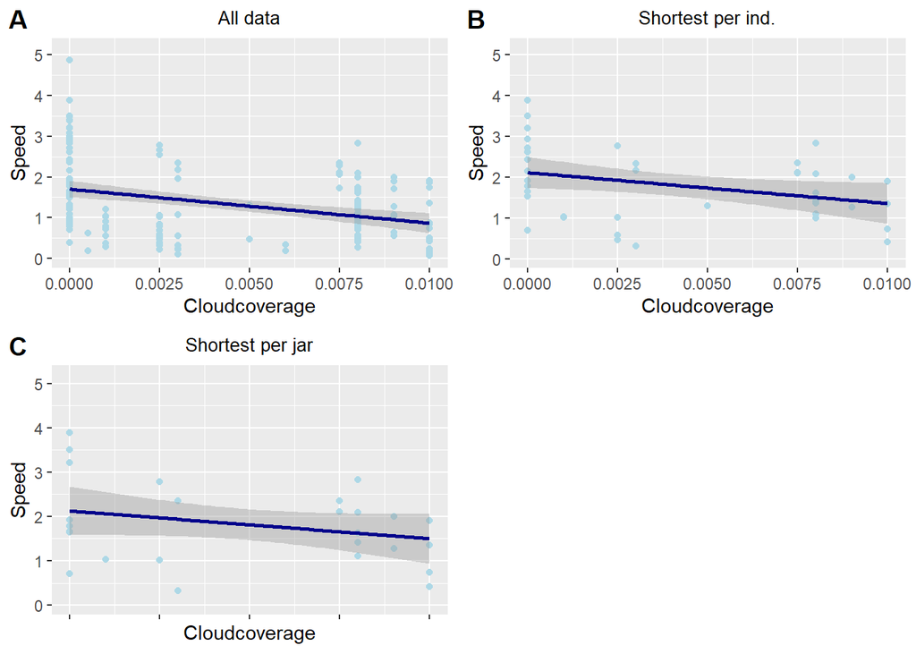

```r
plot13<-ggplot(Flights_incomplete, aes(x=Cloudcoverage, y=Speed)) + geom_point(color="lightblue") + geom_smooth(method="lm", formula =y ~ x, se=TRUE, fullrange=FALSE, level=0.95, color="darkblue") + ggtitle("All data")+ theme(plot.title = element_text(hjust = 0.5, size=10))

plot14<-ggplot(Shortind_incomplete, aes(x=Cloudcoverage, y=Speed)) + geom_point(color="lightblue") + geom_smooth(method="lm", formula =y ~ x, se=TRUE, fullrange=FALSE, level=0.95, color="darkblue") + ggtitle("Shortest per ind.") + theme(plot.title = element_text(hjust = 0.5, size=10))

plot15<-ggplot(Shortpot_incomplete, aes(x=Cloudcoverage, y=Speed)) + geom_point(color="lightblue") + geom_smooth(method="lm", formula =y ~ x,  se=TRUE, fullrange=FALSE, level=0.95, color="darkblue") + ggtitle("Shortest per jar")+ theme(plot.title = element_text(hjust = 0.5, size=10))

ggarrange(plot13, plot14, plot15 + rremove("x.text"),
          labels = c("A", "B", "C"),
          ncol = 2, nrow = 2)
```

### Model Ouput

**All data**

```r
model_cloud_all<-lm(Speed ~ Cloudcoverage, na.action=na.exclude, data=Flights_incomplete)
summary(model_cloud_all)
```

```
##
## Call:
## lm(formula = Speed ~ Cloudcoverage, data = Flights_incomplete,
##     na.action = na.exclude)
##
## Residuals:
##     Min      1Q  Median      3Q     Max
## -1.4701 -0.7350 -0.1352  0.7090  3.1686
##
## Coefficients:
##               Estimate Std. Error t value Pr(>|t|)
## (Intercept)     1.7028     0.1042  16.341  < 2e-16 ***
## Cloudcoverage -83.5246    17.9820  -4.645 6.84e-06 ***
## ---
## Signif. codes:  0 '***' 0.001 '**' 0.01 '*' 0.05 '.' 0.1 ' ' 1
##
## Residual standard error: 0.9054 on 168 degrees of freedom
##   (121 observations deleted due to missingness)
## Multiple R-squared:  0.1138, Adjusted R-squared:  0.1085
## F-statistic: 21.58 on 1 and 168 DF,  p-value: 6.837e-06
```

Hoogsignificant

**Shortest per individual**

```r
model_cloud_ind<-lm(Speed ~ Cloudcoverage, na.action=na.exclude, data=Shortind_incomplete)
summary(model_cloud_ind)
```

```
##
## Call:
## lm(formula = Speed ~ Cloudcoverage, data = Shortind_incomplete,
##     na.action = na.exclude)
##
## Residuals:
##      Min       1Q   Median       3Q      Max
## -1.56953 -0.51565 -0.00941  0.56006  1.77008
##
## Coefficients:
##               Estimate Std. Error t value Pr(>|t|)
## (Intercept)     2.1195     0.1894  11.191 9.63e-14 ***
## Cloudcoverage -75.4818    34.1964  -2.207   0.0332 *
## ---
## Signif. codes:  0 '***' 0.001 '**' 0.01 '*' 0.05 '.' 0.1 ' ' 1
##
## Residual standard error: 0.8471 on 39 degrees of freedom
##   (100 observations deleted due to missingness)
## Multiple R-squared:  0.1111, Adjusted R-squared:  0.08826
## F-statistic: 4.872 on 1 and 39 DF,  p-value: 0.03324
```

Minder significant

**Shortest per jar**

```r
model_cloud_pot<-lm(Speed ~ Cloudcoverage, na.action=na.exclude, data=Shortpot_incomplete)
summary(model_cloud_pot)
```

```
##
## Call:
## lm(formula = Speed ~ Cloudcoverage, data = Shortpot_incomplete,
##     na.action = na.exclude)
##
## Residuals:
##     Min      1Q  Median      3Q     Max
## -1.6156 -0.4998 -0.1438  0.4617  1.7619
##
## Coefficients:
##               Estimate Std. Error t value Pr(>|t|)
## (Intercept)     2.1277     0.2677   7.949 2.64e-08 ***
## Cloudcoverage -62.8640    42.2781  -1.487     0.15
## ---
## Signif. codes:  0 '***' 0.001 '**' 0.01 '*' 0.05 '.' 0.1 ' ' 1
##
## Residual standard error: 0.8788 on 25 degrees of freedom
##   (117 observations deleted due to missingness)
## Multiple R-squared:  0.08125,    Adjusted R-squared:  0.0445
## F-statistic: 2.211 on 1 and 25 DF,  p-value: 0.1495
```

Niet significant

## 7) Speed vs Weight individual

### Graphs

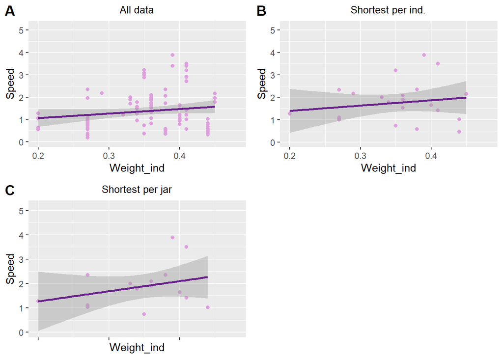

```r
plot16<-ggplot(Flights_incomplete, aes(x=Weight_ind, y=Speed)) + geom_point(color="plum") + geom_smooth(method="lm", formula =y ~ x, se=TRUE, fullrange=FALSE, level=0.95, color="darkorchid4") + ggtitle("All data")+ theme(plot.title = element_text(hjust = 0.5, size=10))

plot17<-ggplot(Shortind_incomplete, aes(x=Weight_ind, y=Speed)) + geom_point(color="plum") + geom_smooth(method="lm", formula =y ~ x, se=TRUE, fullrange=FALSE, level=0.95, color="darkorchid4") + ggtitle("Shortest per ind.") + theme(plot.title = element_text(hjust = 0.5, size=10))

plot18<-ggplot(Shortpot_incomplete, aes(x=Weight_ind, y=Speed)) + geom_point(color="plum") + geom_smooth(method="lm", formula =y ~ x,  se=TRUE, fullrange=FALSE, level=0.95, color="darkorchid4") + ggtitle("Shortest per jar")+ theme(plot.title = element_text(hjust = 0.5, size=10))

ggarrange(plot16, plot17, plot18 + rremove("x.text"),
          labels = c("A", "B", "C"),
          ncol = 2, nrow = 2)
```

### Model Output

**All data**

```r
model_weight_all<-lm(Speed ~ Weight_ind, na.action=na.exclude, data=Flights_incomplete)
summary(model_weight_all)
```

```
##
## Call:
## lm(formula = Speed ~ Weight_ind, data = Flights_incomplete, na.action = na.exclude)
##
## Residuals:
##     Min      1Q  Median      3Q     Max
## -1.2333 -0.5984 -0.1359  0.4395  2.4383
##
## Coefficients:
##             Estimate Std. Error t value Pr(>|t|)
## (Intercept)   0.6584     0.4317   1.525   0.1303
## Weight_ind    2.0332     1.2127   1.677   0.0967 .
## ---
## Signif. codes:  0 '***' 0.001 '**' 0.01 '*' 0.05 '.' 0.1 ' ' 1
##
## Residual standard error: 0.845 on 102 degrees of freedom
##   (187 observations deleted due to missingness)
## Multiple R-squared:  0.02682,    Adjusted R-squared:  0.01728
## F-statistic: 2.811 on 1 and 102 DF,  p-value: 0.0967
```

Niet significant

**Shortest per individual**

```r
model_weight_ind<-lm(Speed ~ Weight_ind, na.action=na.exclude, data=Shortind_incomplete)
summary(model_weight_ind)
```

```
##
## Call:
## lm(formula = Speed ~ Weight_ind, data = Shortind_incomplete,
##     na.action = na.exclude)
##
## Residuals:
##     Min      1Q  Median      3Q     Max
## -1.5007 -0.5405 -0.1287  0.4190  2.0398
##
## Coefficients:
##             Estimate Std. Error t value Pr(>|t|)
## (Intercept)   0.9285     1.0310   0.901    0.378
## Weight_ind    2.3621     2.9168   0.810    0.427
##
## Residual standard error: 0.9133 on 21 degrees of freedom
##   (118 observations deleted due to missingness)
## Multiple R-squared:  0.03028,    Adjusted R-squared:  -0.0159
## F-statistic: 0.6558 on 1 and 21 DF,  p-value: 0.4271
```

Niet significant

**Shortest per jar**

```r
model_weight_pot<-lm(Speed ~ Weight_ind, na.action=na.exclude, data=Shortpot_incomplete)
summary(model_weight_pot)
```

```
##
## Call:
## lm(formula = Speed ~ Weight_ind, data = Shortpot_incomplete,
##     na.action = na.exclude)
##
## Residuals:
##      Min       1Q   Median       3Q      Max
## -1.25226 -0.49260 -0.02368  0.26291  1.83161
##
## Coefficients:
##             Estimate Std. Error t value Pr(>|t|)
## (Intercept)   0.4392     1.2420   0.354    0.729
## Weight_ind    4.1507     3.5355   1.174    0.261
##
## Residual standard error: 0.883 on 13 degrees of freedom
##   (129 observations deleted due to missingness)
## Multiple R-squared:  0.09586,    Adjusted R-squared:  0.02631
## F-statistic: 1.378 on 1 and 13 DF,  p-value: 0.2615
```

Niet significant

## 8.1) Speed vs Windspeed

### Graphs

Telkens voor de modellen Speed ~ Windspeed en Speed ~ Windspeed + Windspeed²

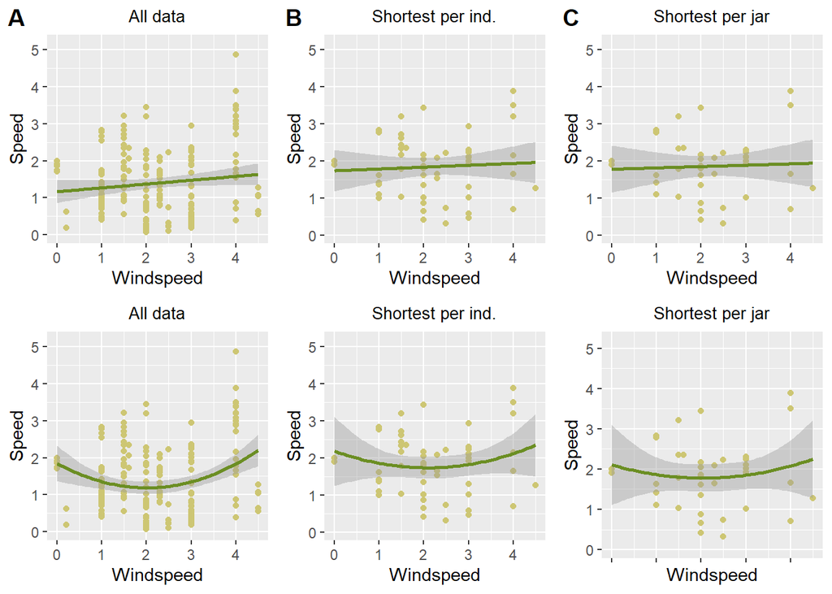

```r
plot19<-ggplot(Flights_incomplete, aes(x=Windspeed, y=Speed)) + geom_point(color="khaki3") + geom_smooth(method="lm", formula =y ~ x, se=TRUE, fullrange=FALSE, level=0.95, color="olivedrab") + ggtitle("All data")+ theme(plot.title = element_text(hjust = 0.5, size=10))

plot20<-ggplot(Shortind_incomplete, aes(x=Windspeed, y=Speed)) + geom_point(color="khaki3") + geom_smooth(method="lm", formula =y ~ x, se=TRUE, fullrange=FALSE, level=0.95, color="olivedrab") + ggtitle("Shortest per ind.") + theme(plot.title = element_text(hjust = 0.5, size=10))

plot21<-ggplot(Shortpot_incomplete, aes(x=Windspeed, y=Speed)) + geom_point(color="khaki3") + geom_smooth(method="lm", formula =y ~ x,  se=TRUE, fullrange=FALSE, level=0.95, color="olivedrab") + ggtitle("Shortest per jar")+ theme(plot.title = element_text(hjust = 0.5, size=10))

plot22<-ggplot(Flights_incomplete, aes(x=Windspeed, y=Speed)) + geom_point(color="khaki3") + geom_smooth(method="lm", formula =y ~ x + I(x^2), se=TRUE, fullrange=FALSE, level=0.95, color="olivedrab") + ggtitle("All data")+ theme(plot.title = element_text(hjust = 0.5, size=10))

plot23<-ggplot(Shortind_incomplete, aes(x=Windspeed, y=Speed)) + geom_point(color="khaki3") + geom_smooth(method="lm", formula =y ~ x + I(x^2), se=TRUE, fullrange=FALSE, level=0.95, color="olivedrab") + ggtitle("Shortest per ind.") + theme(plot.title = element_text(hjust = 0.5, size=10))

plot24<-ggplot(Shortpot_incomplete, aes(x=Windspeed, y=Speed)) + geom_point(color="khaki3") + geom_smooth(method="lm", formula =y ~ x + I(x^2),  se=TRUE, fullrange=FALSE, level=0.95, color="olivedrab") + ggtitle("Shortest per jar")+ theme(plot.title = element_text(hjust = 0.5, size=10))

ggarrange(plot19, plot20, plot21, plot22, plot23, plot24 + rremove("x.text"),
          labels = c("A", "B", "C"),
          ncol = 3, nrow = 2)
```

### Model Output

**All data**

```r
model_wind_all<-lm(Speed ~ Windspeed, na.action=na.exclude, data=Flights_incomplete)
summary(model_wind_all)
```

```
##
## Call:
## lm(formula = Speed ~ Windspeed, data = Flights_incomplete, na.action = na.exclude)
##
## Residuals:
##     Min      1Q  Median      3Q     Max
## -1.3312 -0.7841 -0.1695  0.6339  3.2929
##
## Coefficients:
##             Estimate Std. Error t value Pr(>|t|)
## (Intercept)  1.16531    0.15486   7.525 2.06e-12 ***
## Windspeed    0.10331    0.06086   1.698   0.0912 .
## ---
## Signif. codes:  0 '***' 0.001 '**' 0.01 '*' 0.05 '.' 0.1 ' ' 1
##
## Residual standard error: 0.939 on 190 degrees of freedom
##   (99 observations deleted due to missingness)
## Multiple R-squared:  0.01494,    Adjusted R-squared:  0.009756
## F-statistic: 2.882 on 1 and 190 DF,  p-value: 0.09122
```

```r
model_wind2_all<-lm(Speed ~ Windspeed + I(Windspeed^2), na.action=na.exclude, data=Flights_incomplete)
summary(model_wind2_all)
```

```
##
## Call:
## lm(formula = Speed ~ Windspeed + I(Windspeed^2), data = Flights_incomplete,
##     na.action = na.exclude)
##
## Residuals:
##     Min      1Q  Median      3Q     Max
## -1.6412 -0.7999 -0.1447  0.6237  3.0397
##
## Coefficients:
##                Estimate Std. Error t value Pr(>|t|)
## (Intercept)     1.84723    0.24438   7.559 1.71e-12 ***
## Windspeed      -0.65631    0.22258  -2.949 0.003595 **
## I(Windspeed^2)  0.16311    0.04608   3.540 0.000504 ***
## ---
## Signif. codes:  0 '***' 0.001 '**' 0.01 '*' 0.05 '.' 0.1 ' ' 1
##
## Residual standard error: 0.9118 on 189 degrees of freedom
##   (99 observations deleted due to missingness)
## Multiple R-squared:  0.07619,    Adjusted R-squared:  0.06641
## F-statistic: 7.793 on 2 and 189 DF,  p-value: 0.0005594
```

Tweedegraadsmodel significant

**Shortest per individual**

```r
model_wind_ind<-lm(Speed ~ Windspeed, na.action=na.exclude, data=Shortind_incomplete)
summary(model_wind_ind)
```

```
##
## Call:
## lm(formula = Speed ~ Windspeed, data = Shortind_incomplete, na.action = na.exclude)
##
## Residuals:
##      Min       1Q   Median       3Q      Max
## -1.54331 -0.66338  0.06847  0.40259  1.94806
##
## Coefficients:
##             Estimate Std. Error t value Pr(>|t|)
## (Intercept)  1.74237    0.27698   6.290 6.68e-08 ***
## Windspeed    0.04979    0.11197   0.445    0.658
## ---
## Signif. codes:  0 '***' 0.001 '**' 0.01 '*' 0.05 '.' 0.1 ' ' 1
##
## Residual standard error: 0.8458 on 52 degrees of freedom
##   (87 observations deleted due to missingness)
## Multiple R-squared:  0.003788,   Adjusted R-squared:  -0.01537
## F-statistic: 0.1977 on 1 and 52 DF,  p-value: 0.6584
```

```r
model_wind2_ind<-lm(Speed ~ Windspeed + I(Windspeed^2), na.action=na.exclude, data=Shortind_incomplete)
summary(model_wind2_ind)
```

```
##
## Call:
## lm(formula = Speed ~ Windspeed + I(Windspeed^2), data = Shortind_incomplete,
##     na.action = na.exclude)
##
## Residuals:
##      Min       1Q   Median       3Q      Max
## -1.43701 -0.67341  0.04594  0.47391  1.76773
##
## Coefficients:
##                Estimate Std. Error t value Pr(>|t|)
## (Intercept)     2.18954    0.46487   4.710 1.94e-05 ***
## Windspeed      -0.42939    0.41618  -1.032    0.307
## I(Windspeed^2)  0.10312    0.08629   1.195    0.238
## ---
## Signif. codes:  0 '***' 0.001 '**' 0.01 '*' 0.05 '.' 0.1 ' ' 1
##
## Residual standard error: 0.8423 on 51 degrees of freedom
##   (87 observations deleted due to missingness)
## Multiple R-squared:  0.03093,    Adjusted R-squared:  -0.007077
## F-statistic: 0.8138 on 2 and 51 DF,  p-value: 0.4489
```

Beide niet signifcant

**Shortest per jar**

```r
model_wind_pot<-lm(Speed ~ Windspeed, na.action=na.exclude, data=Shortpot_incomplete)
summary(model_wind_pot)
```

```
##
## Call:
## lm(formula = Speed ~ Windspeed, data = Shortpot_incomplete, na.action = na.exclude)
##
## Residuals:
##      Min       1Q   Median       3Q      Max
## -1.55173 -0.54524  0.06694  0.35623  1.96031
##
## Coefficients:
##             Estimate Std. Error t value Pr(>|t|)
## (Intercept)  1.78522    0.31423   5.681 1.56e-06 ***
## Windspeed    0.03601    0.12772   0.282    0.779
## ---
## Signif. codes:  0 '***' 0.001 '**' 0.01 '*' 0.05 '.' 0.1 ' ' 1
##
## Residual standard error: 0.8397 on 38 degrees of freedom
##   (104 observations deleted due to missingness)
## Multiple R-squared:  0.002088,   Adjusted R-squared:  -0.02417
## F-statistic: 0.07952 on 1 and 38 DF,  p-value: 0.7795
```

```r
model_wind2_pot<-lm(Speed ~ Windspeed + I(Windspeed^2), na.action=na.exclude, data=Shortpot_incomplete)
summary(model_wind2_pot)
```

```
##
## Call:
## lm(formula = Speed ~ Windspeed + I(Windspeed^2), data = Shortpot_incomplete,
##     na.action = na.exclude)
##
## Residuals:
##      Min       1Q   Median       3Q      Max
## -1.47133 -0.52545  0.04179  0.41653  1.81400
##
## Coefficients:
##                Estimate Std. Error t value Pr(>|t|)
## (Intercept)     2.10470    0.49257   4.273  0.00013 ***
## Windspeed      -0.31836    0.43881  -0.726  0.47270
## I(Windspeed^2)  0.07777    0.09210   0.844  0.40385
## ---
## Signif. codes:  0 '***' 0.001 '**' 0.01 '*' 0.05 '.' 0.1 ' ' 1
##
## Residual standard error: 0.8429 on 37 degrees of freedom
##   (104 observations deleted due to missingness)
## Multiple R-squared:  0.02096,    Adjusted R-squared:  -0.03196
## F-statistic: 0.396 on 2 and 37 DF,  p-value: 0.6758
```

## 8.2) Speed vs Windspeed | afhankelijk van de windrichting

Hiervoor werd telkens voor elke meting nagegaan of de hoornaar met meewind (tailwind), tegenwind (upwind) of loodrechte wind (perpendicular) te maken had. Dit volgens de formules:

|𝜃flight −𝜃wind| ≤ 45 is tailwind

45 < |𝜃flight −𝜃wind|<135 is (quasi) perpendicular

|𝜃 flight −𝜃wind| ≥135 upwind

### Graphs

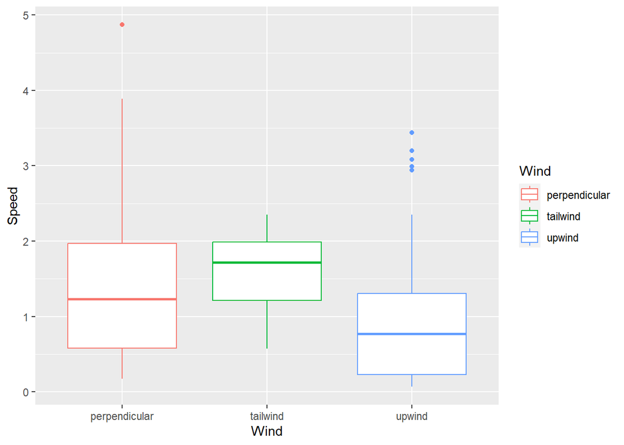

```r
ggplot(data=subset(Flights_incomplete, !is.na(Wind)), aes(x= Wind, col=Wind, y=Speed)) + geom_boxplot()
```

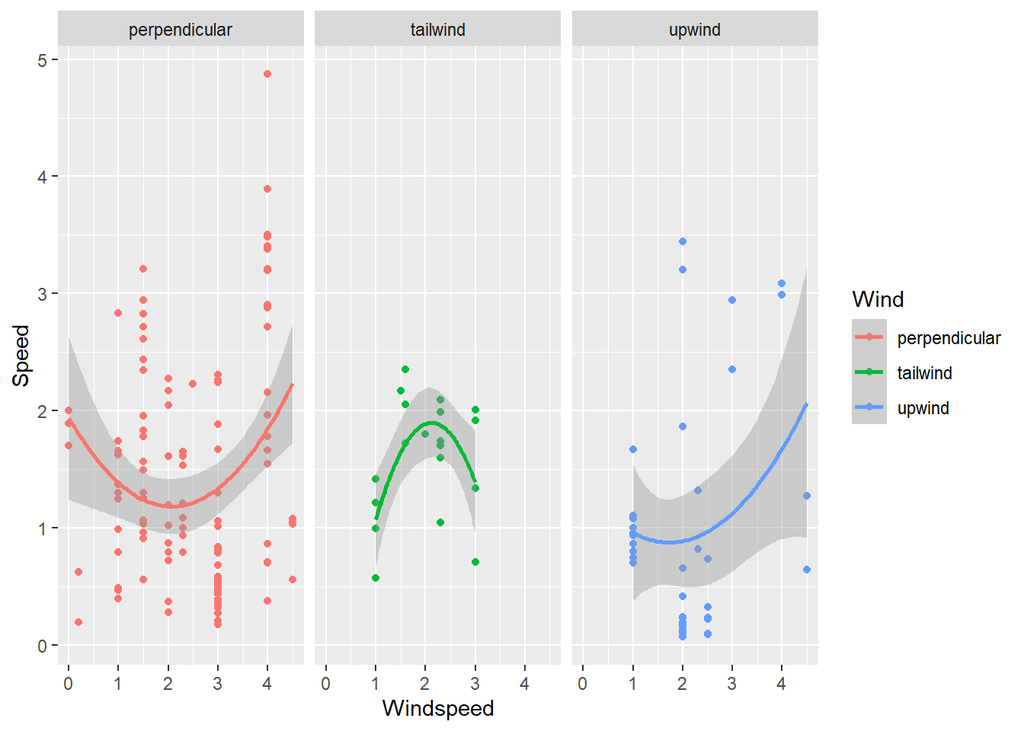

```r
ggplot(data=subset(Flights_incomplete, !is.na(Wind)), aes(x= Windspeed, col=Wind, y=Speed)) + geom_point() + facet_grid(~Wind) + geom_smooth(method="lm", formula = y ~ x + I(x^2), se=TRUE, fullrange=FALSE, level=0.95)
```

### Model Output

```r
data_tailwind<-Flights_incomplete %>%  filter(Wind!="tailwind")
data_perpendicular<-Flights_incomplete %>%  filter(Wind!="perpendicular")
data_upwind<-Flights_incomplete %>%  filter(Wind!="upwind")

model_tailwind<-lm(Speed ~ Windspeed + I(Windspeed^2), na.action=na.exclude, data=data_tailwind)
summary(model_tailwind)
```

```
##
## Call:
## lm(formula = Speed ~ Windspeed + I(Windspeed^2), data = data_tailwind,
##     na.action = na.exclude)
##
## Residuals:
##     Min      1Q  Median      3Q     Max
## -1.6904 -0.8094 -0.1842  0.5865  3.0392
##
## Coefficients:
##                Estimate Std. Error t value Pr(>|t|)
## (Intercept)     1.81108    0.32082   5.645 7.66e-08 ***
## Windspeed      -0.72555    0.28272  -2.566  0.01122 *
## I(Windspeed^2)  0.18271    0.05618   3.252  0.00141 **
## ---
## Signif. codes:  0 '***' 0.001 '**' 0.01 '*' 0.05 '.' 0.1 ' ' 1
##
## Residual standard error: 0.9522 on 155 degrees of freedom
##   (9 observations deleted due to missingness)
## Multiple R-squared:  0.09666,    Adjusted R-squared:  0.085
## F-statistic: 8.292 on 2 and 155 DF,  p-value: 0.000379
```

```r
model_perpendicular<-lm(Speed ~ Windspeed + I(Windspeed^2), na.action=na.exclude, data=data_perpendicular)
summary(model_perpendicular)
```

```
##
## Call:
## lm(formula = Speed ~ Windspeed + I(Windspeed^2), data = data_perpendicular,
##     na.action = na.exclude)
##
## Residuals:
##      Min       1Q   Median       3Q      Max
## -1.29415 -0.72654 -0.06112  0.61255  2.26622
##
## Coefficients:
##                Estimate Std. Error t value Pr(>|t|)
## (Intercept)     1.03426    0.58765   1.760   0.0839 .
## Windspeed      -0.03328    0.52138  -0.064   0.9493
## I(Windspeed^2)  0.05194    0.10549   0.492   0.6244
## ---
## Signif. codes:  0 '***' 0.001 '**' 0.01 '*' 0.05 '.' 0.1 ' ' 1
##
## Residual standard error: 0.8802 on 56 degrees of freedom
##   (6 observations deleted due to missingness)
## Multiple R-squared:  0.05014,    Adjusted R-squared:  0.01621
## F-statistic: 1.478 on 2 and 56 DF,  p-value: 0.2369
```

```r
model_upwind<-lm(Speed ~ Windspeed + I(Windspeed^2), na.action=na.exclude, data=data_upwind)
summary(model_upwind)
```

```
##
## Call:
## lm(formula = Speed ~ Windspeed + I(Windspeed^2), data = data_upwind,
##     na.action = na.exclude)
##
## Residuals:
##      Min       1Q   Median       3Q      Max
## -1.60494 -0.82862 -0.06998  0.59595  3.03158
##
## Coefficients:
##                Estimate Std. Error t value Pr(>|t|)
## (Intercept)     1.82065    0.31993   5.691 7.28e-08 ***
## Windspeed      -0.56097    0.28415  -1.974   0.0504 .
## I(Windspeed^2)  0.14144    0.05729   2.469   0.0148 *
## ---
## Signif. codes:  0 '***' 0.001 '**' 0.01 '*' 0.05 '.' 0.1 ' ' 1
##
## Residual standard error: 0.9042 on 138 degrees of freedom
##   (7 observations deleted due to missingness)
## Multiple R-squared:  0.06185,    Adjusted R-squared:  0.04825
## F-statistic: 4.549 on 2 and 138 DF,  p-value: 0.01221
```

## 9) Flight error vs urbanisation (25m, 50m, 100m)

Flight error is the difference between the actual angle from the bait to the nest and the flight direction I measured.

### Graphs

#### Urbanisatiecirkels

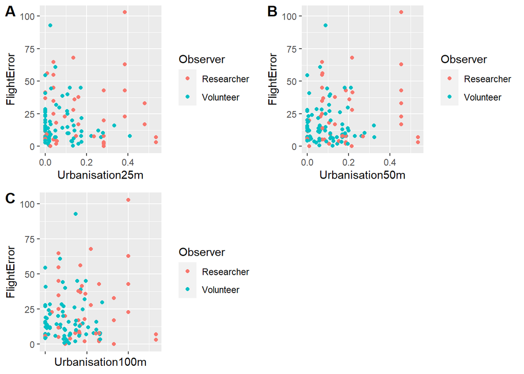

```r
plot25<-ggplot(data=subset(Flights_incomplete, !is.na(Observer)), aes(x=Urbanisation25m, y=FlightError, fill=Observer)) + geom_point(aes(color=Observer))

plot26<-ggplot(data=subset(Flights_incomplete, !is.na(Observer)), aes(x=Urbanisation50m, y=FlightError, fill=Observer)) + geom_point(aes(color=Observer))

plot27<-ggplot(data=subset(Flights_incomplete, !is.na(Observer)), aes(x=Urbanisation100m, y=FlightError, fill=Observer)) + geom_point(aes(color=Observer))

ggarrange(plot25, plot26, plot27 + rremove("x.text"),
          labels = c("A", "B", "C"),
          ncol = 2, nrow = 2)
```

De foutmarge tussen mij en vrijwilligers lijkt evengroot

```r
library(circular)
Errorcirc<-circular(Flights_incomplete$FlightError, type=c("angles"), units=c("degrees"), rotation=c("clock"), zero=0)

lm.circular(Errorcirc, Flights_incomplete$Urbanisation25m, type=c("c-l"), init=c(1))
```

```
##
## Call:
## lm.circular.cl(y = ..1, x = ..2, init = ..3)
##
##
##  Circular-Linear Regression
##
##  Coefficients:
##      Estimate Std. Error t value Pr(>|t|)
## [1,]  0.04652    0.04128   1.127     0.13
##
##  Log-Likelihood:  449.2
##
##  Summary: (mu in radians)
##   mu:  15.96 ( 1.039 )  kappa:  11.48 ( 0.9501 )
## p-values are approximated using normal distribution
```

Moet ik 1 invullen bij init? “a vector with initial values of length equal to the columns of x”

```r
lm.circular(Errorcirc, Flights_incomplete$Urbanisation50m, type=c("c-l"), init=c(1))
```

```
##
## Call:
## lm.circular.cl(y = ..1, x = ..2, init = ..3)
##
##
##  Circular-Linear Regression
##
##  Coefficients:
##      Estimate Std. Error t value Pr(>|t|)
## [1,]  0.06414    0.04088   1.569   0.0583 .
## ---
## Signif. codes:  0 '***' 0.001 '**' 0.01 '*' 0.05 '.' 0.1 ' ' 1
##
##  Log-Likelihood:  449.4
##
##  Summary: (mu in radians)
##   mu:  16.4 ( 1.039 )  kappa:  11.49 ( 0.9512 )
## p-values are approximated using normal distribution
```

Niet significant

```r
lm.circular(Errorcirc, Flights_incomplete$Urbanisation100m, type=c("c-l"), init=c(1))
```

```
##
## Call:
## lm.circular.cl(y = ..1, x = ..2, init = ..3)
##
##
##  Circular-Linear Regression
##
##  Coefficients:
##      Estimate Std. Error t value Pr(>|t|)
## [1,]  0.15496    0.03974     3.9 4.82e-05 ***
## ---
## Signif. codes:  0 '***' 0.001 '**' 0.01 '*' 0.05 '.' 0.1 ' ' 1
##
##  Log-Likelihood:  451.5
##
##  Summary: (mu in radians)
##   mu:  18.42 ( 1.031 )  kappa:  11.66 ( 0.9655 )
## p-values are approximated using normal distribution
```

Significant

#### Urbanisatietrajecten

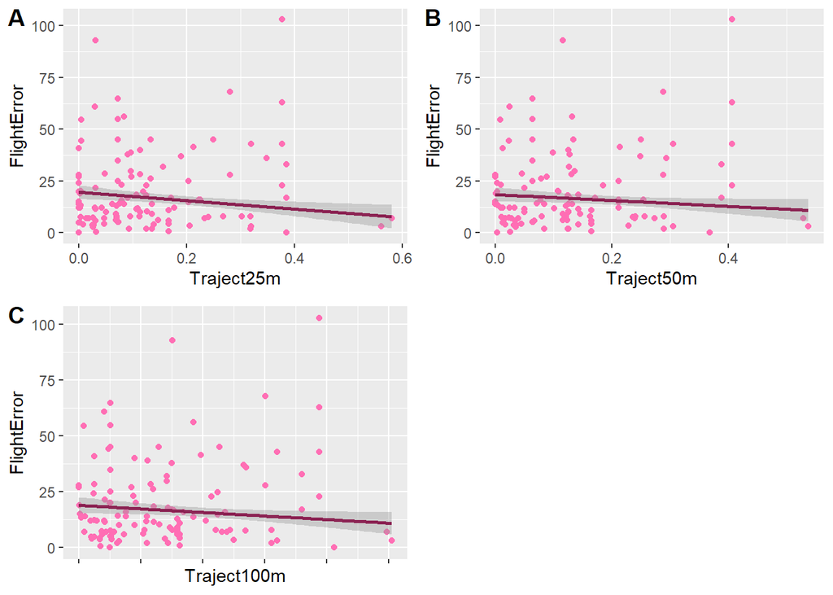

```r
plot28<-ggplot(data=subset(Flights_incomplete, !is.na(Observer)), aes(x=Traject25m, y=FlightError)) + geom_point(col="hotpink1") + geom_smooth(method="lm", formula =y ~ x, se=TRUE, fullrange=FALSE, level=0.95, color="violetred4")

plot29<-ggplot(data=subset(Flights_incomplete, !is.na(Observer)), aes(x=Traject50m, y=FlightError)) + geom_point(col="hotpink1") + geom_smooth(method="lm", formula =y ~ x , se=TRUE, fullrange=FALSE, level=0.95, color="violetred4")

plot30<-ggplot(data=subset(Flights_incomplete, !is.na(Observer)), aes(x=Traject100m, y=FlightError)) + geom_point(col="hotpink1")+ geom_smooth(method="lm", formula =y ~ x, se=TRUE, fullrange=FALSE, level=0.95, color="violetred4")

ggarrange(plot28, plot29, plot30 + rremove("x.text"),
          labels = c("A", "B", "C"),
          ncol = 2, nrow = 2)
```

## 10) Speed vs Urbanisation

### Graphs

Urbanisatiecirkels niet berekend, meteen trajecten genomen want die zijn betere maatstaf

#### Alle data

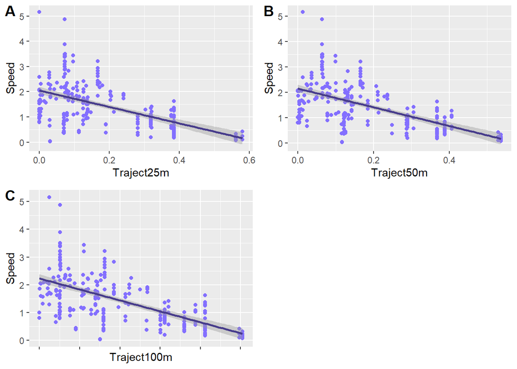

```r
plot31<-ggplot(data=subset(Flights_incomplete, !is.na(Observer)), aes(x=Traject25m, y=Speed)) + geom_point(col="slateblue1") + geom_smooth(method="lm", formula =y ~ x, se=TRUE, fullrange=FALSE, level=0.95, color="slateblue4")

plot32<-ggplot(data=subset(Flights_incomplete, !is.na(Observer)), aes(x=Traject50m, y=Speed)) + geom_point(col="slateblue1") + geom_smooth(method="lm", formula =y ~ x, se=TRUE, fullrange=FALSE, level=0.95, color="slateblue4")

plot33<-ggplot(data=subset(Flights_incomplete, !is.na(Observer)), aes(x=Traject100m, y=Speed)) + geom_point(col="slateblue1") + geom_smooth(method="lm", formula =y ~ x, se=TRUE, fullrange=FALSE, level=0.95, color="slateblue4")

ggarrange(plot31, plot32, plot33 + rremove("x.text"),
          labels = c("A", "B", "C"),
          ncol = 2, nrow = 2)
```

#### Shortest per individual

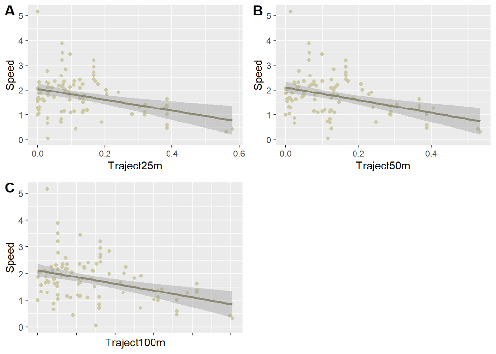

```r
plot34<-ggplot(data=subset(Shortind_incomplete, !is.na(Observer)), aes(x=Traject25m, y=Speed)) + geom_point(col="lemonchiffon3") + geom_smooth(method="lm", formula =y ~ x, se=TRUE, fullrange=FALSE, level=0.95, color="lemonchiffon4")

plot35<-ggplot(data=subset(Shortind_incomplete, !is.na(Observer)), aes(x=Traject50m, y=Speed)) + geom_point(col="lemonchiffon3") +
geom_smooth(method="lm", formula =y ~ x, se=TRUE, fullrange=FALSE, level=0.95, color="lemonchiffon4")

plot36<-ggplot(data=subset(Shortind_incomplete, !is.na(Observer)), aes(x=Traject100m, y=Speed)) + geom_point(col="lemonchiffon3") + geom_smooth(method="lm", formula =y ~ x, se=TRUE, fullrange=FALSE, level=0.95, color="lemonchiffon4")

ggarrange(plot34, plot35, plot36 + rremove("x.text"),
          labels = c("A", "B", "C"),
          ncol = 2, nrow = 2)
```

#### Shortest per pot

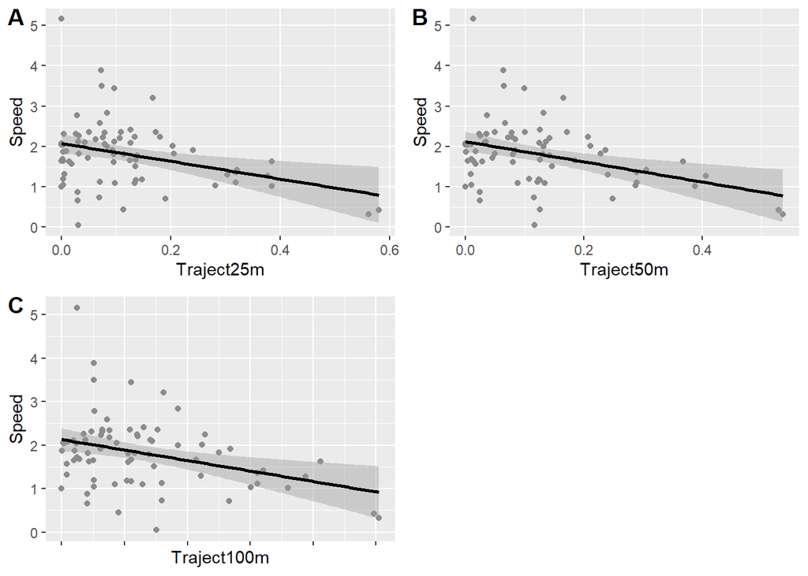

```r
plot37<-ggplot(data=subset(Shortpot_incomplete, !is.na(Observer)), aes(x=Traject25m, y=Speed)) + geom_point(col="grey55") + geom_smooth(method="lm", formula =y ~ x, se=TRUE, fullrange=FALSE, level=0.95, color="black")

plot38<-ggplot(data=subset(Shortpot_incomplete, !is.na(Observer)), aes(x=Traject50m, y=Speed)) + geom_point(col="grey55") +
geom_smooth(method="lm", formula =y ~ x, se=TRUE, fullrange=FALSE, level=0.95, color="black")

plot39<-ggplot(data=subset(Shortpot_incomplete, !is.na(Observer)), aes(x=Traject100m, y=Speed)) + geom_point(col="grey55") + geom_smooth(method="lm", formula =y ~ x, se=TRUE, fullrange=FALSE, level=0.95, color="black")

ggarrange(plot37, plot38, plot39 + rremove("x.text"),
          labels = c("A", "B", "C"),
          ncol = 2, nrow = 2)
```

### Model Output

**All data**

```r
model_urb25_all<-lm(Speed ~ Traject25m, na.action=na.exclude, data=Flights_incomplete)
summary(model_urb25_all)
```

```
##
## Call:
## lm(formula = Speed ~ Traject25m, data = Flights_incomplete, na.action = na.exclude)
##
## Residuals:
##      Min       1Q   Median       3Q      Max
## -1.92429 -0.42644 -0.04567  0.34699  3.10844
##
## Coefficients:
##             Estimate Std. Error t value Pr(>|t|)
## (Intercept)  2.05005    0.07402   27.69   <2e-16 ***
## Traject25m  -3.26268    0.29806  -10.95   <2e-16 ***
## ---
## Signif. codes:  0 '***' 0.001 '**' 0.01 '*' 0.05 '.' 0.1 ' ' 1
##
## Residual standard error: 0.7542 on 254 degrees of freedom
##   (35 observations deleted due to missingness)
## Multiple R-squared:  0.3205, Adjusted R-squared:  0.3179
## F-statistic: 119.8 on 1 and 254 DF,  p-value: < 2.2e-16
```

```r
model_urb50_all<-lm(Speed ~ Traject50m, na.action=na.exclude, data=Flights_incomplete)
summary(model_urb50_all)
```

```
##
## Call:
## lm(formula = Speed ~ Traject50m, data = Flights_incomplete, na.action = na.exclude)
##
## Residuals:
##      Min       1Q   Median       3Q      Max
## -1.68876 -0.44510 -0.05134  0.35670  3.06136
##
## Coefficients:
##             Estimate Std. Error t value Pr(>|t|)
## (Intercept)  2.14249    0.07521   28.49   <2e-16 ***
## Traject50m  -3.68101    0.30663  -12.01   <2e-16 ***
## ---
## Signif. codes:  0 '***' 0.001 '**' 0.01 '*' 0.05 '.' 0.1 ' ' 1
##
## Residual standard error: 0.7308 on 254 degrees of freedom
##   (35 observations deleted due to missingness)
## Multiple R-squared:  0.362,  Adjusted R-squared:  0.3595
## F-statistic: 144.1 on 1 and 254 DF,  p-value: < 2.2e-16
```

```r
model_urb100_all<-lm(Speed ~ Traject100m, na.action=na.exclude, data=Flights_incomplete)
summary(model_urb100_all)
```

```
##
## Call:
## lm(formula = Speed ~ Traject100m, data = Flights_incomplete,
##     na.action = na.exclude)
##
## Residuals:
##     Min      1Q  Median      3Q     Max
## -1.6094 -0.4245 -0.0646  0.3780  3.0276
##
## Coefficients:
##             Estimate Std. Error t value Pr(>|t|)
## (Intercept)  2.22896    0.07723   28.86   <2e-16 ***
## Traject100m -3.94081    0.30899  -12.75   <2e-16 ***
## ---
## Signif. codes:  0 '***' 0.001 '**' 0.01 '*' 0.05 '.' 0.1 ' ' 1
##
## Residual standard error: 0.7143 on 254 degrees of freedom
##   (35 observations deleted due to missingness)
## Multiple R-squared:  0.3904, Adjusted R-squared:  0.388
## F-statistic: 162.7 on 1 and 254 DF,  p-value: < 2.2e-16
```

**Shortest per individual**

```r
model_urb25_ind<-lm(Speed ~ Traject25m, na.action=na.exclude, data=Shortind_incomplete)
summary(model_urb25_ind)
```

```
##
## Call:
## lm(formula = Speed ~ Traject25m, data = Shortind_incomplete,
##     na.action = na.exclude)
##
## Residuals:
##      Min       1Q   Median       3Q      Max
## -1.93649 -0.48344 -0.00336  0.37724  3.11060
##
## Coefficients:
##             Estimate Std. Error t value Pr(>|t|)
## (Intercept)   2.0478     0.1105  18.532  < 2e-16 ***
## Traject25m   -2.1879     0.6183  -3.538 0.000622 ***
## ---
## Signif. codes:  0 '***' 0.001 '**' 0.01 '*' 0.05 '.' 0.1 ' ' 1
##
## Residual standard error: 0.7766 on 96 degrees of freedom
##   (43 observations deleted due to missingness)
## Multiple R-squared:  0.1154, Adjusted R-squared:  0.1062
## F-statistic: 12.52 on 1 and 96 DF,  p-value: 0.0006225
```

```r
model_urb50_ind<-lm(Speed ~ Traject50m, na.action=na.exclude, data=Shortind_incomplete)
summary(model_urb50_ind)
```

```
##
## Call:
## lm(formula = Speed ~ Traject50m, data = Shortind_incomplete,
##     na.action = na.exclude)
##
## Residuals:
##      Min       1Q   Median       3Q      Max
## -1.76413 -0.48197 -0.03905  0.35473  3.08715
##
## Coefficients:
##             Estimate Std. Error t value Pr(>|t|)
## (Intercept)   2.1025     0.1139  18.461  < 2e-16 ***
## Traject50m   -2.5292     0.6406  -3.948  0.00015 ***
## ---
## Signif. codes:  0 '***' 0.001 '**' 0.01 '*' 0.05 '.' 0.1 ' ' 1
##
## Residual standard error: 0.7659 on 96 degrees of freedom
##   (43 observations deleted due to missingness)
## Multiple R-squared:  0.1397, Adjusted R-squared:  0.1307
## F-statistic: 15.59 on 1 and 96 DF,  p-value: 0.0001502
```

```r
model_urb100_ind<-lm(Speed ~ Traject100m, na.action=na.exclude, data=Shortind_incomplete)
summary(model_urb100_ind)
```

```
##
## Call:
## lm(formula = Speed ~ Traject100m, data = Shortind_incomplete,
##     na.action = na.exclude)
##
## Residuals:
##     Min      1Q  Median      3Q     Max
## -1.6973 -0.5099 -0.0363  0.3813  3.0997
##
## Coefficients:
##             Estimate Std. Error t value Pr(>|t|)
## (Intercept)   2.1215     0.1187  17.871  < 2e-16 ***
## Traject100m  -2.5209     0.6493  -3.882  0.00019 ***
## ---
## Signif. codes:  0 '***' 0.001 '**' 0.01 '*' 0.05 '.' 0.1 ' ' 1
##
## Residual standard error: 0.7676 on 96 degrees of freedom
##   (43 observations deleted due to missingness)
## Multiple R-squared:  0.1357, Adjusted R-squared:  0.1267
## F-statistic: 15.07 on 1 and 96 DF,  p-value: 0.0001898
```

**Shortest per jar**

```r
model_urb25_pot<-lm(Speed ~ Traject25m, na.action=na.exclude, data=Shortpot_incomplete)
summary(model_urb25_pot)
```

```
##
## Call:
## lm(formula = Speed ~ Traject25m, data = Shortpot_incomplete,
##     na.action = na.exclude)
##
## Residuals:
##      Min       1Q   Median       3Q      Max
## -1.96156 -0.42145 -0.01949  0.36450  3.08530
##
## Coefficients:
##             Estimate Std. Error t value Pr(>|t|)
## (Intercept)   2.0731     0.1217  17.033   <2e-16 ***
## Traject25m   -2.1953     0.7207  -3.046   0.0032 **
## ---
## Signif. codes:  0 '***' 0.001 '**' 0.01 '*' 0.05 '.' 0.1 ' ' 1
##
## Residual standard error: 0.7805 on 75 degrees of freedom
##   (67 observations deleted due to missingness)
## Multiple R-squared:  0.1101, Adjusted R-squared:  0.09824
## F-statistic:  9.28 on 1 and 75 DF,  p-value: 0.003197
```

```r
model_urb50_pot<-lm(Speed ~ Traject50m, na.action=na.exclude, data=Shortpot_incomplete)
summary(model_urb50_pot)
```

```
##
## Call:
## lm(formula = Speed ~ Traject50m, data = Shortpot_incomplete,
##     na.action = na.exclude)
##
## Residuals:
##     Min      1Q  Median      3Q     Max
## -1.7863 -0.4256 -0.0427  0.3398  3.0687
##
## Coefficients:
##             Estimate Std. Error t value Pr(>|t|)
## (Intercept)   2.1205     0.1260  16.830  < 2e-16 ***
## Traject50m   -2.4930     0.7483  -3.332  0.00134 **
## ---
## Signif. codes:  0 '***' 0.001 '**' 0.01 '*' 0.05 '.' 0.1 ' ' 1
##
## Residual standard error: 0.7722 on 75 degrees of freedom
##   (67 observations deleted due to missingness)
## Multiple R-squared:  0.1289, Adjusted R-squared:  0.1173
## F-statistic:  11.1 on 1 and 75 DF,  p-value: 0.001342
```

```r
model_urb100_pot<-lm(Speed ~ Traject100m, na.action=na.exclude, data=Shortpot_incomplete)
summary(model_urb100_pot)
```

```
##
## Call:
## lm(formula = Speed ~ Traject100m, data = Shortpot_incomplete,
##     na.action = na.exclude)
##
## Residuals:
##      Min       1Q   Median       3Q      Max
## -1.72209 -0.39922 -0.03187  0.36796  3.08865
##
## Coefficients:
##             Estimate Std. Error t value Pr(>|t|)
## (Intercept)   2.1298     0.1327  16.053  < 2e-16 ***
## Traject100m  -2.4119     0.7686  -3.138  0.00243 **
## ---
## Signif. codes:  0 '***' 0.001 '**' 0.01 '*' 0.05 '.' 0.1 ' ' 1
##
## Residual standard error: 0.7779 on 75 degrees of freedom
##   (67 observations deleted due to missingness)
## Multiple R-squared:  0.1161, Adjusted R-squared:  0.1043
## F-statistic: 9.847 on 1 and 75 DF,  p-value: 0.002432
```

## 10) Flight time vs Distance + Temperatuur + Urbanisation

Aangezien temperatuur en urbanisatie de beste predictoren zijn kunnen we ze eens samen in een model steken.

```r
model_1_all<-lm(Flighttime_min ~ Distance + Temperature + Traject25m, na.action=na.exclude, data=Flights_incomplete)
summary(model_1_all)
```

```
##
## Call:
## lm(formula = Flighttime_min ~ Distance + Temperature + Traject25m,
##     data = Flights_incomplete, na.action = na.exclude)
##
## Residuals:
##     Min      1Q  Median      3Q     Max
## -5.0650 -1.2657 -0.4641  0.5966 13.7417
##
## Coefficients:
##               Estimate Std. Error t value Pr(>|t|)
## (Intercept)  3.8614296  1.2969803   2.977  0.00327 **
## Distance     0.0054290  0.0003401  15.964  < 2e-16 ***
## Temperature -0.1177242  0.0527266  -2.233  0.02669 *
## Traject25m   2.1620327  1.6989643   1.273  0.20467
## ---
## Signif. codes:  0 '***' 0.001 '**' 0.01 '*' 0.05 '.' 0.1 ' ' 1
##
## Residual standard error: 2.321 on 197 degrees of freedom
##   (90 observations deleted due to missingness)
## Multiple R-squared:  0.5764, Adjusted R-squared:  0.5699
## F-statistic: 89.34 on 3 and 197 DF,  p-value: < 2.2e-16
```

```r
model_2_all<-lm(Flighttime_min ~ Distance + Temperature + Traject50m, na.action=na.exclude, data=Flights_incomplete)
summary(model_2_all)
```

```
##
## Call:
## lm(formula = Flighttime_min ~ Distance + Temperature + Traject50m,
##     data = Flights_incomplete, na.action = na.exclude)
##
## Residuals:
##     Min      1Q  Median      3Q     Max
## -5.0623 -1.2131 -0.4681  0.6204 13.7568
##
## Coefficients:
##               Estimate Std. Error t value Pr(>|t|)
## (Intercept)  3.8965337  1.3216470   2.948  0.00358 **
## Distance     0.0054588  0.0003444  15.848  < 2e-16 ***
## Temperature -0.1208982  0.0522534  -2.314  0.02172 *
## Traject50m   2.2112349  1.8252480   1.211  0.22717
## ---
## Signif. codes:  0 '***' 0.001 '**' 0.01 '*' 0.05 '.' 0.1 ' ' 1
##
## Residual standard error: 2.322 on 197 degrees of freedom
##   (90 observations deleted due to missingness)
## Multiple R-squared:  0.576,  Adjusted R-squared:  0.5696
## F-statistic: 89.22 on 3 and 197 DF,  p-value: < 2.2e-16
```

```r
model_3_all<-lm(Flighttime_min ~ Distance + Temperature + Traject100m, na.action=na.exclude, data=Flights_incomplete)
summary(model_3_all)
```

```
##
## Call:
## lm(formula = Flighttime_min ~ Distance + Temperature + Traject100m,
##     data = Flights_incomplete, na.action = na.exclude)
##
## Residuals:
##     Min      1Q  Median      3Q     Max
## -5.1167 -1.1775 -0.4536  0.4959 13.6327
##
## Coefficients:
##               Estimate Std. Error t value Pr(>|t|)
## (Intercept)  3.0987530  1.3792679   2.247   0.0258 *
## Distance     0.0055742  0.0003538  15.757   <2e-16 ***
## Temperature -0.0987567  0.0520420  -1.898   0.0592 .
## Traject100m  3.5496513  1.9761551   1.796   0.0740 .
## ---
## Signif. codes:  0 '***' 0.001 '**' 0.01 '*' 0.05 '.' 0.1 ' ' 1
##
## Residual standard error: 2.312 on 197 degrees of freedom
##   (90 observations deleted due to missingness)
## Multiple R-squared:  0.5798, Adjusted R-squared:  0.5734
## F-statistic:  90.6 on 3 and 197 DF,  p-value: < 2.2e-16
```

## 11) Speed vs Temperatuur + Urbanisation

```r
model_4_all<-lm(Speed ~ Temperature + Traject25m, na.action=na.exclude, data=Flights_incomplete)
summary(model_4_all)
```

```
##
## Call:
## lm(formula = Speed ~ Temperature + Traject25m, data = Flights_incomplete,
##     na.action = na.exclude)
##
## Residuals:
##      Min       1Q   Median       3Q      Max
## -1.71612 -0.40700 -0.04595  0.38487  2.65383
##
## Coefficients:
##             Estimate Std. Error t value Pr(>|t|)
## (Intercept)  0.24768    0.36952   0.670 0.503457
## Temperature  0.08043    0.01460   5.509 1.11e-07 ***
## Traject25m  -1.67292    0.48086  -3.479 0.000619 ***
## ---
## Signif. codes:  0 '***' 0.001 '**' 0.01 '*' 0.05 '.' 0.1 ' ' 1
##
## Residual standard error: 0.6619 on 198 degrees of freedom
##   (90 observations deleted due to missingness)
## Multiple R-squared:  0.5021, Adjusted R-squared:  0.4971
## F-statistic: 99.85 on 2 and 198 DF,  p-value: < 2.2e-16
```

```r
model_5_all<-lm(Speed ~ Temperature + Traject50m, na.action=na.exclude, data=Flights_incomplete)
summary(model_5_all)
```

```
##
## Call:
## lm(formula = Speed ~ Temperature + Traject50m, data = Flights_incomplete,
##     na.action = na.exclude)
##
## Residuals:
##      Min       1Q   Median       3Q      Max
## -1.75074 -0.35923 -0.03298  0.38169  2.62425
##
## Coefficients:
##             Estimate Std. Error t value Pr(>|t|)
## (Intercept)  0.58138    0.36958   1.573    0.117
## Temperature  0.06955    0.01437   4.839 2.62e-06 ***
## Traject50m  -2.24136    0.50068  -4.477 1.28e-05 ***
## ---
## Signif. codes:  0 '***' 0.001 '**' 0.01 '*' 0.05 '.' 0.1 ' ' 1
##
## Residual standard error: 0.6497 on 198 degrees of freedom
##   (90 observations deleted due to missingness)
## Multiple R-squared:  0.5203, Adjusted R-squared:  0.5154
## F-statistic: 107.4 on 2 and 198 DF,  p-value: < 2.2e-16
```

```r
model_6_all<-lm(Speed ~ Temperature + Traject100m, na.action=na.exclude, data=Flights_incomplete)
summary(model_6_all)
```

```
##
## Call:
## lm(formula = Speed ~ Temperature + Traject100m, data = Flights_incomplete,
##     na.action = na.exclude)
##
## Residuals:
##      Min       1Q   Median       3Q      Max
## -1.75478 -0.34565 -0.04651  0.35029  2.54733
##
## Coefficients:
##             Estimate Std. Error t value Pr(>|t|)
## (Intercept)  1.02424    0.37273   2.748 0.006551 **
## Temperature  0.05575    0.01416   3.937 0.000114 ***
## Traject100m -2.93590    0.51308  -5.722 3.85e-08 ***
## ---
## Signif. codes:  0 '***' 0.001 '**' 0.01 '*' 0.05 '.' 0.1 ' ' 1
##
## Residual standard error: 0.6316 on 198 degrees of freedom
##   (90 observations deleted due to missingness)
## Multiple R-squared:  0.5467, Adjusted R-squared:  0.5421
## F-statistic: 119.4 on 2 and 198 DF,  p-value: < 2.2e-16
```

## Varpart

library(vegan) varpart(Flights_incomplete$Flighttime_min, ~Distance, ~Temperatuur, ~Windspeed, na.action=na.exclude, data= Flights_incomplete)

**TO DO** - circulaire statistiek verder uitwerken ?

## Statistische modellen probeersels

```r
# Model kiezen
library(car)
```

```r
library(carData)
library(leaps)
select1<-regsubsets(Speed ~ Temperature + Cloudcoverage + Windspeed + Weight_ind, na.action=na.exclude, data=Flights_incomplete, nbest=3)
summary(select1)
```

```
## Subset selection object
## Call: regsubsets.formula(Speed ~ Temperature + Cloudcoverage + Windspeed +
##     Weight_ind, na.action = na.exclude, data = Flights_incomplete,
##     nbest = 3)
## 4 Variables  (and intercept)
##               Forced in Forced out
## Temperature       FALSE      FALSE
## Cloudcoverage     FALSE      FALSE
## Windspeed         FALSE      FALSE
## Weight_ind        FALSE      FALSE
## 3 subsets of each size up to 4
## Selection Algorithm: exhaustive
##          Temperature Cloudcoverage Windspeed Weight_ind
## 1  ( 1 ) "*"         " "           " "       " "
## 1  ( 2 ) " "         " "           "*"       " "
## 1  ( 3 ) " "         " "           " "       "*"
## 2  ( 1 ) "*"         " "           " "       "*"
## 2  ( 2 ) "*"         " "           "*"       " "
## 2  ( 3 ) "*"         "*"           " "       " "
## 3  ( 1 ) "*"         "*"           " "       "*"
## 3  ( 2 ) "*"         " "           "*"       "*"
## 3  ( 3 ) "*"         "*"           "*"       " "
## 4  ( 1 ) "*"         "*"           "*"       "*"
```

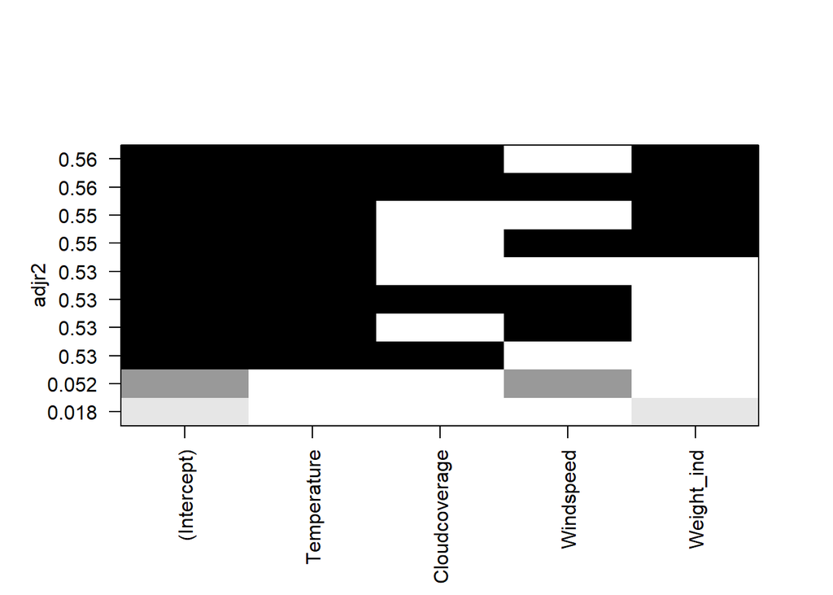

```r
plot(select1, scale="adjr2")
```

```r
select2<-regsubsets(Speed ~ Temperature + Cloudcoverage + Windspeed + Weight_ind + Temperature*Cloudcoverage + Temperature*Windspeed + Temperature*Weight_ind + Cloudcoverage*Windspeed + Cloudcoverage*Weight_ind + Windspeed*Weight_ind, na.action=na.exclude, data=Flights_incomplete, nbest=3)
summary(select2)
```

```
## Subset selection object
## Call: regsubsets.formula(Speed ~ Temperature + Cloudcoverage + Windspeed +
##     Weight_ind + Temperature * Cloudcoverage + Temperature *
##     Windspeed + Temperature * Weight_ind + Cloudcoverage * Windspeed +
##     Cloudcoverage * Weight_ind + Windspeed * Weight_ind, na.action = na.exclude,
##     data = Flights_incomplete, nbest = 3)
## 10 Variables  (and intercept)
##                           Forced in Forced out
## Temperature                   FALSE      FALSE
## Cloudcoverage                 FALSE      FALSE
## Windspeed                     FALSE      FALSE
## Weight_ind                    FALSE      FALSE
## Temperature:Cloudcoverage     FALSE      FALSE
## Temperature:Windspeed         FALSE      FALSE
## Temperature:Weight_ind        FALSE      FALSE
```

[output cut: 80 more lines]

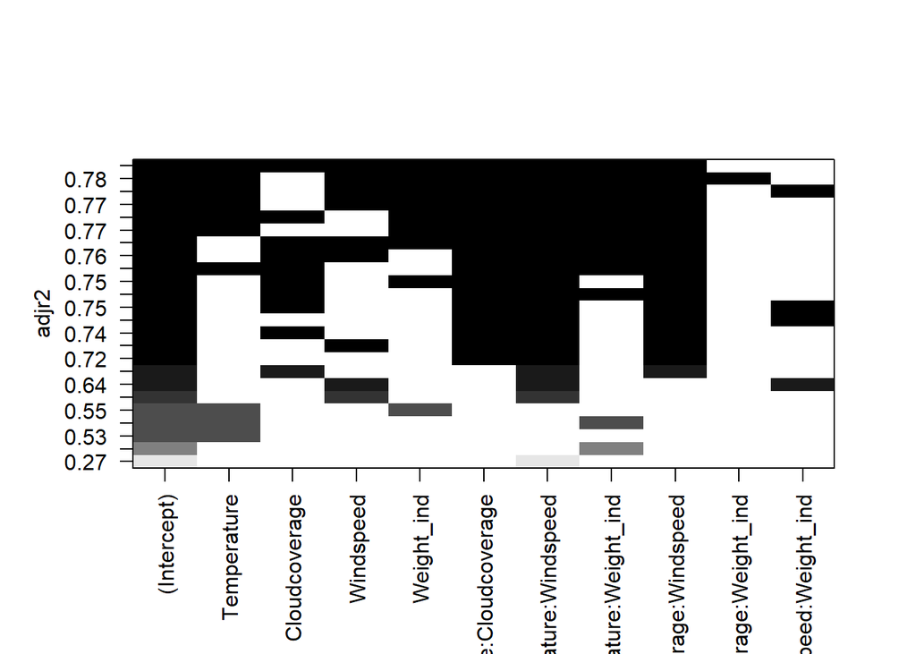

```r
plot(select2, scale="adjr2")
```

### Beste model zonder interacties

```r
model1<-lm(Speed ~ Temperature + Weight_ind, na.action=na.exclude, data=Flights_incomplete)
summary(model1)
```

```
##
## Call:
## lm(formula = Speed ~ Temperature + Weight_ind, data = Flights_incomplete,
##     na.action = na.exclude)
##
## Residuals:
##      Min       1Q   Median       3Q      Max
## -1.37521 -0.36360 -0.00579  0.34045  1.37419
##
## Coefficients:
##             Estimate Std. Error t value Pr(>|t|)
## (Intercept)  -2.2464     0.3930  -5.716 1.13e-07 ***
## Temperature   0.1577     0.0143  11.027  < 2e-16 ***
## Weight_ind    1.8220     0.8173   2.229    0.028 *
## ---
## Signif. codes:  0 '***' 0.001 '**' 0.01 '*' 0.05 '.' 0.1 ' ' 1
##
## Residual standard error: 0.5693 on 100 degrees of freedom
##   (188 observations deleted due to missingness)
## Multiple R-squared:  0.561,  Adjusted R-squared:  0.5522
## F-statistic:  63.9 on 2 and 100 DF,  p-value: < 2.2e-16
```

### Beste model met 2e graadsinteracties - 1 interactie

```r
model2_2<-lm(Speed ~ Temperature + Cloudcoverage + Windspeed + Cloudcoverage*Windspeed, na.action=na.exclude, data=Flights_incomplete)
summary(model2_2)
```

```
##
## Call:
## lm(formula = Speed ~ Temperature + Cloudcoverage + Windspeed +
##     Cloudcoverage * Windspeed, data = Flights_incomplete, na.action = na.exclude)
##
## Residuals:
##      Min       1Q   Median       3Q      Max
## -1.85213 -0.34399 -0.00032  0.33285  2.20248
##
## Coefficients:
##                          Estimate Std. Error t value Pr(>|t|)
## (Intercept)              -1.79273    0.28806  -6.223 3.87e-09 ***
## Temperature               0.14607    0.01169  12.496  < 2e-16 ***
## Cloudcoverage           108.51279   27.39356   3.961 0.000111 ***
## Windspeed                 0.16596    0.06701   2.477 0.014270 *
## Cloudcoverage:Windspeed -42.76103   10.48801  -4.077 7.08e-05 ***
## ---
## Signif. codes:  0 '***' 0.001 '**' 0.01 '*' 0.05 '.' 0.1 ' ' 1
##
## Residual standard error: 0.6191 on 165 degrees of freedom
##   (121 observations deleted due to missingness)
## Multiple R-squared:  0.593,  Adjusted R-squared:  0.5832
## F-statistic: 60.11 on 4 and 165 DF,  p-value: < 2.2e-16
```

### Beste model met 2e graadsinteracties - 4 interacties

```r
# 4 interacties
model2_1<-lm(Speed ~ Temperature + Cloudcoverage + Windspeed + Weight_ind + Temperature*Cloudcoverage + Temperature*Windspeed + Temperature*Weight_ind + Cloudcoverage*Windspeed, na.action=na.exclude, data=Flights_incomplete)
summary(model2_1)
```

```
##
## Call:
## lm(formula = Speed ~ Temperature + Cloudcoverage + Windspeed +
##     Weight_ind + Temperature * Cloudcoverage + Temperature *
##     Windspeed + Temperature * Weight_ind + Cloudcoverage * Windspeed,
##     data = Flights_incomplete, na.action = na.exclude)
##
## Residuals:
##      Min       1Q   Median       3Q      Max
## -0.89394 -0.28411  0.00689  0.23553  0.96049
##
## Coefficients:
##                             Estimate Std. Error t value Pr(>|t|)
## (Intercept)                 -4.83590    1.67072  -2.895  0.00472 **
## Temperature                  0.30742    0.09279   3.313  0.00131 **
## Cloudcoverage             -296.06616  109.05701  -2.715  0.00789 **
## Windspeed                   -1.01503    0.36230  -2.802  0.00617 **
## Weight_ind                  19.54364    4.96872   3.933  0.00016 ***
## Temperature:Cloudcoverage   25.08236    5.93348   4.227 5.48e-05 ***
## Temperature:Windspeed        0.07722    0.01660   4.652 1.07e-05 ***
## Temperature:Weight_ind      -1.13997    0.26691  -4.271 4.65e-05 ***
## Cloudcoverage:Windspeed    -83.76352   13.49610  -6.206 1.45e-08 ***
## ---
## Signif. codes:  0 '***' 0.001 '**' 0.01 '*' 0.05 '.' 0.1 ' ' 1
##
## Residual standard error: 0.3913 on 94 degrees of freedom
##   (188 observations deleted due to missingness)
## Multiple R-squared:  0.805,  Adjusted R-squared:  0.7884
## F-statistic: 48.52 on 8 and 94 DF,  p-value: < 2.2e-16
```

## Multicollinearity check

```r
library(ggcorrplot)
modelvif<-lm(Speed ~ Temperature + Cloudcoverage + Windspeed + Weight_ind, na.action=na.exclude, data=Flights_incomplete)
vif(modelvif)
```

```
##   Temperature Cloudcoverage     Windspeed    Weight_ind
##      1.133119      1.325336      1.200633      1.145246
```

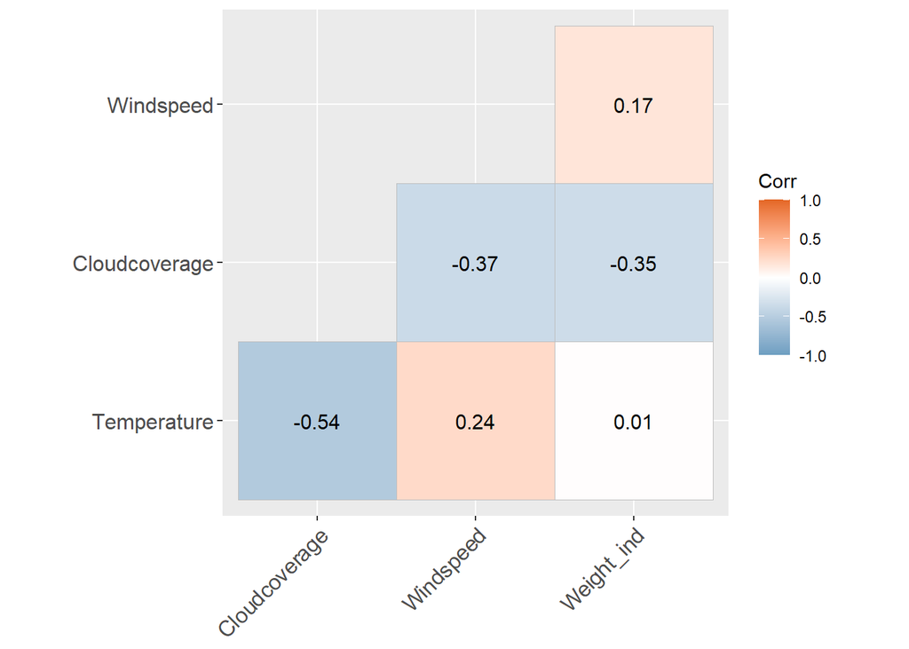

```r
datacor<-Flights_incomplete[, c("Temperature", "Cloudcoverage", "Windspeed", "Weight_ind")]
cormat <- round(cor(datacor, use = "pairwise.complete.obs"), 2)
ggcorrplot(cormat, lab= TRUE, type = "lower", ggtheme = ggplot2::theme_gray,
   colors = c("#6D9EC1", "white", "#E46726"))
```

##PCA

```r
library(vegan)
```

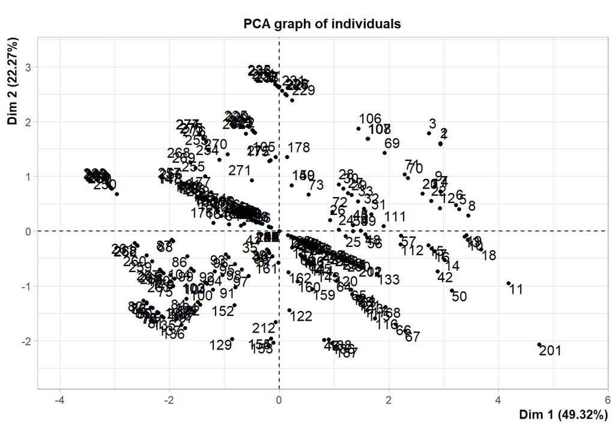

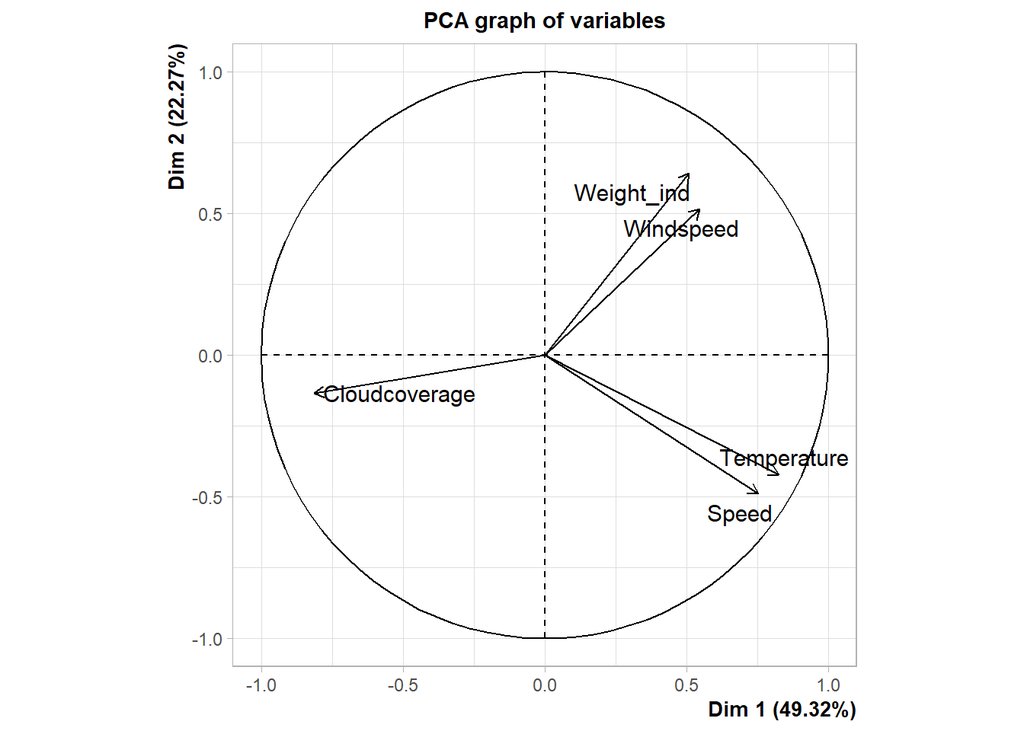

```r
library(missMDA)
library(FactoMineR)
datapca<-select(Flights_incomplete, Cloudcoverage, Windspeed, Temperature, Speed, Weight_ind)
nb <- estim_ncpPCA(datapca, scale = TRUE)
comp<-imputePCA(datapca, ncp=2)
res<-PCA(comp$completeObs)
```